# chromosomix against reference implementations

## 24 · CTCF sites in GM12878 (Fig. 2)

Fig. 2 chains four tasks, and this section runs the chain twice, each link by chromosomix and by the package it reproduces, on the same inputs: in situ Hi-C of GM12878 (Rao et al. 2014; 4DN’s 4DNFIXP4QG5B, every replicate merged, 4,010,478,943 contacts) at 10 kb; CTCF ChIP-seq of two labs as the two replicates — ENCODE’s ENCSR000AKB (Bernstein lab, Broad) and ENCSR000DRZ (Stamatoyannopoulos lab, UW), each the fold change over control of its pooled replicates; and ATAC-seq (ENCSR095QNB). The map is 27 GB, and what both sides read of it is the 10-kb rung of chr19 — and for Fig. 2’s own pileup the 2-kb one — every contact within it with the file’s own weights, read by range from 4DN’s bucket into a `.cool` (`notebooks/scripts/cool_subset.py`, which writes a pixel the file stores twice once, as the sum both tools read it as); the tracks are cut to chr19 interval for interval, as § 5 cuts its replicates, and for § 5’s reason: yapc holds the second derivative of everything it is given in memory and writes it out, 700 MB a seed for two chromosomes. Each link is fed what the one before it wrote **in chromosomix**, so the chain is the app’s and every reference is held to one step of it.

1. **Insulation at four scales**: windows of 50, 100, 200 and 400 kb, against `cooltools.insulation` with the four, and the boundaries called on the narrowest, which is the window the app calls them on.
2. **CTCF’s peaks**: the two labs’ tracks as replicates, against yapc 0.1 with IDR 2.0.3 at § 5’s settings, five seeds.
3. **APA between consecutive peaks**: each peak of 2 paired with the next along its chromosome — by the app’s own *consecutive features*, and for coolpuppy by a BEDPE of the same pairs written here — piled up raw and over the expected, at coolpuppy’s defaults and with every pair, against coolpuppy with § 11’s script and settings; and Fig. 2’s own panel, on the 2-kb rung, ten bins either side from coolpuppy’s floor for that window, over the expected. There one peak’s midpoint sits half a base before a bin edge, and the two tools agree only if both round it down. And the TADs between the boundaries of 1, on the 2-kb rung, each with half its length either side, stretched evenly onto 51 cells a side over the expected, against coolpuppy’s rescaled local pileup.
4. **The signal at CTCF’s sites**: the metaplot of both CTCF tracks and ATAC-seq about each peak’s centre, ±2 kb in 50-bp bins, and of the insulation at its four scales, ±500 kb in 10-kb bins, against deepTools’ `computeMatrix reference-point`, `plotProfile` and `plotHeatmap`.

|  | chromosomix | reference |
| --- | --- | --- |
| insulation | `insulation --window 5 --scales 4` | `cooltools.insulation(…, [50_000, 100_000, 200_000, 400_000])`, § 1’s other settings |
| peaks | `peaks --signal ENCFF734CUT --replicate ENCFF644EEX`, § 5’s settings | `yapc`, § 5’s settings, seeds 0–4 |
| pairs | `apa --anchors consecutive --features` the peaks: each and the next on its chromosome | a BEDPE of each peak and the next, written here |
| APA | `apa --anchors consecutive --mode fixed --window 5 --minDiag 2 --minDist 12` (or `0`), `--norm none` or `oe` | `coolpup.pileup(…, flank=50_000)`, `mindist` `'auto'` (or `0`), raw or over § 4’s expected for this map |
| APA, Fig. 2 | the same at 2 kb: `--window 10 --minDiag 2 --minDist 22 --norm oe` | `coolpup.pileup(…, flank=20_000)`, `mindist` `'auto'`, over the 2-kb rung’s expected |
| TADs | `apa --anchors features --features` the domains `--mode scaled --grid 51 --flankFraction 0.5 --minDiag 2 --norm oe`, at 2 kb | `coolpup.pileup(…, local=True, rescale=True, rescale_flank=0.5, rescale_size=51)`, over the 2-kb rung’s expected |
| metaplot | `metaplot --at centre --stranded=false --band none`, `--flank 2000 --step 50` or `--flank 500000 --step 10000` | `computeMatrix reference-point --referencePoint center`, `-b/-a 2000 --binSize 50` or `-b/-a 500000 --binSize 10000` |

```python
GM = WORK / 'gm12878'
GM_ANALYSIS = 'CTCF sites in GM12878 (Fig. 2)'
GM_SEQUENCES = ['chr19']
GM_MAP = f'{FOURDN}/d6abea45-b0bb-4154-9854-1d3075b98097/4DNFIXP4QG5B.mcool'
GM_COOL = DATA / '4DNFIXP4QG5B_10000.chr19.cool'
if not GM_COOL.exists():
    subprocess.run([PYTHON, str(SCRIPTS / 'cool_subset.py'), GM_MAP, '10000', str(GM_COOL), '--sequences',
                    ','.join(GM_SEQUENCES)], check=True)
GM_10K = rel(GM_COOL)


def cut(source, sequences=GM_SEQUENCES):
    """The track with these sequences only, interval for interval: § 5's cut, for more than one."""
    target = DATA / f"{source.stem}.{'-'.join(sequences)}.bw"
    if target.exists() and not REDO:
        return target
    handle = pyBigWig.open(str(source))
    out = pyBigWig.open(str(target), 'w')
    out.addHeader([(name, handle.chroms()[name]) for name in sequences])
    for name in sequences:
        entries = handle.intervals(name) or ()
        out.addEntries([name] * len(entries), [int(a) for a, _, _ in entries],
                       ends=[int(b) for _, b, _ in entries], values=[float(v) for _, _, v in entries])
    out.close()
    handle.close()
    return target


CTCF = [cut(PATHS[a]) for a in ('ENCFF734CUT', 'ENCFF644EEX')]
GM_ATAC = cut(PATHS['ENCFF487LOB'])
clr_gm = cooler.Cooler(str(GM_COOL))
gm_bins = clr_gm.bins()[:]
measures({'map': f"4DNFIXP4QG5B, {', '.join(GM_SEQUENCES)} at 10 kb: {len(gm_bins):,} bins, "
                 f"{clr_gm.info['nnz']:,} pixels, {clr_gm.info['sum']:,} contacts",
          'CTCF, the two replicates': ', '.join(rel(path) for path in CTCF), 'ATAC-seq': rel(GM_ATAC)})
```

| measure | value |
| --- | --- |
| map | 4DNFIXP4QG5B, chr19 at 10 kb: 5,862 bins, 8,490,738 pixels, 78,280,054 contacts |
| CTCF, the two replicates | data/ENCFF734CUT.chr19.bw, data/ENCFF644EEX.chr19.bw |
| ATAC-seq | data/ENCFF487LOB.chr19.bw |

### Insulation at four scales

```python
GI = GM / 'insulation'
GM_WINDOWS = [5, 10, 20, 40]
mr('insulation', GM_10K, '--window', 5, '--scales', 4, out=GI / 'app', name='gm-insulation', analysis=GM_ANALYSIS,
   label='insulation, four scales', group='insulation')
reference('gm-cooltools-insulation', GM_ANALYSIS, 'cooltools',
          [PYTHON, script('cooltools_insulation_scales'), GM_10K, OUT, THREADS, *[w * 10_000 for w in GM_WINDOWS]],
          out=GI / 'cooltools.tsv', label='insulation, four scales', group='insulation', threads=THREADS)

gm_ref_ins = pd.read_csv(GI / 'cooltools.tsv', sep='\t')
gm_ins = {}
for w in GM_WINDOWS:
    app_w = table(one(GI / 'app', f'*.insulation-w{w}.tsv'))
    assert (app_w['bin'].to_numpy() == np.arange(len(gm_bins))).all()
    gm_ins[w] = (app_w['value'].to_numpy(float), gm_ref_ins[f'log2_insulation_score_{w * 10_000}'].to_numpy(float))
gm_both = {w: np.isfinite(a) & np.isfinite(b) for w, (a, b) in gm_ins.items()}
gm_one = {w: int((np.isfinite(a) != np.isfinite(b)).sum()) for w, (a, b) in gm_ins.items()}
gm_diff = {w: np.abs(a[gm_both[w]] - b[gm_both[w]]) for w, (a, b) in gm_ins.items()}
gm_app_b = table(one(GI / 'app', '*.insulation-boundaries.tsv'))
gm_ref_b = gm_ref_ins.loc[gm_ref_ins['is_boundary_50000'].astype(bool), ['chrom', 'start', 'boundary_strength_50000']]
gm_calls = gm_app_b[['chrom', 'start', 'score']].merge(gm_ref_b, on=['chrom', 'start'], how='outer', indicator=True)
gm_same = gm_calls[gm_calls['_merge'] == 'both']
gm_strength = np.abs(gm_same['score'] - gm_same['boundary_strength_50000'])
measures({
    **{f'{w * 10} kb: bins both score; only one; max |difference|':
       f'{gm_both[w].sum():,}; {gm_one[w]}; {gm_diff[w].max():.1e}' for w in GM_WINDOWS},
    'boundaries on 50 kb, chromosomix / cooltools; at the same bin': f'{len(gm_app_b):,} / {len(gm_ref_b):,}; {len(gm_same):,}',
    'boundary strength, max |difference|': f'{gm_strength.max():.1e}',
})
```

```
$ chromosomix insulation data/4DNFIXP4QG5B_10000.chr19.cool --window 5 --scales 4 --out gm12878/insulation/app
$ python ../../scripts/cooltools_insulation_scales.py data/4DNFIXP4QG5B_10000.chr19.cool gm12878/insulation/cooltools.tsv 4 50000 100000 200000 400000
```

| measure | value |
| --- | --- |
| 50 kb: bins both score; only one; max \|difference\| | 5,536; 0; 4.7e-06 |
| 100 kb: bins both score; only one; max \|difference\| | 5,553; 0; 4.8e-06 |
| 200 kb: bins both score; only one; max \|difference\| | 5,562; 0; 5.0e-06 |
| 400 kb: bins both score; only one; max \|difference\| | 5,562; 0; 4.9e-06 |
| boundaries on 50 kb, chromosomix / cooltools; at the same bin | 306 / 306; 306 |
| boundary strength, max \|difference\| | 4.7e-06 |

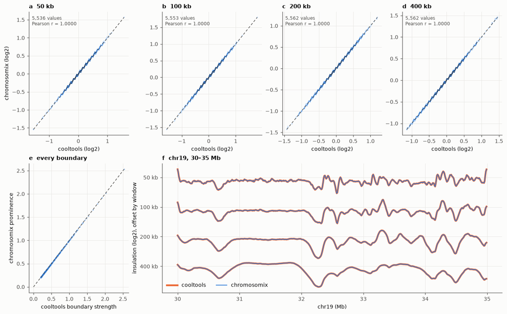

Figure 25: Insulation of GM12878 at 10 kb, chr19. a–d, every bin at each window; e, every boundary both call on the 50-kb window; f, chr19 at 30–35 Mb, the four scales.

```python
TEXT['gm_ins_n'] = f"{sum(gm_both[w].sum() for w in GM_WINDOWS):,}"
TEXT['gm_ins_max'] = f'{max(d.max() for d in gm_diff.values()):.1e}'
TEXT['gm_ins_one'] = f'{sum(gm_one.values())}'
TEXT['gm_calls'] = f'{len(gm_same):,}'
TEXT['gm_calls_only'] = f"{int((gm_calls['_merge'] != 'both').sum())}"
TEXT['gm_strength'] = f'{gm_strength.max():.1e}'

fig = plt.figure(figsize=(12, 7.4), layout='constrained')
grid = fig.add_gridspec(2, 4, height_ratios=[1, 1.05])
for k, w in enumerate(GM_WINDOWS):
    a, b = gm_ins[w]
    agreement(fig.add_subplot(grid[0, k]), b[gm_both[w]], a[gm_both[w]], 'cooltools (log2)',
              'chromosomix (log2)' if k == 0 else '', f'{"abcd"[k]}  {w * 10} kb')
ax = fig.add_subplot(grid[1, 0])
ax.scatter(gm_same['boundary_strength_50000'], gm_same['score'], s=6, color=APP_COLOUR, alpha=0.4, lw=0)
identity(ax, 0, gm_same['boundary_strength_50000'].max())
ax.set(xlabel='cooltools boundary strength', ylabel='chromosomix prominence', title='e  every boundary')
ax = fig.add_subplot(grid[1, 1:])
lo, _ = clr_gm.extent('chr19')
stretch = slice(lo + 3_000, lo + 3_500)
x = gm_bins['start'].to_numpy()[stretch] / 1e6
for k, w in enumerate(GM_WINDOWS):
    a, b = gm_ins[w]
    ax.plot(x, b[stretch] - 1.5 * k, color=REF, lw=3, label='cooltools' if k == 0 else None, gid=f'cooltools, {w * 10} kb')
    ax.plot(x, a[stretch] - 1.5 * k, color=APP_COLOUR, lw=1.2, label='chromosomix' if k == 0 else None,
            gid=f'chromosomix, {w * 10} kb')
ax.set_yticks([-1.5 * k for k in range(len(GM_WINDOWS))], [f'{w * 10} kb' for w in GM_WINDOWS])
ax.set(xlabel='chr19 (Mb)', ylabel='insulation (log2), offset by window', title='f  chr19, 30–35 Mb')
ax.legend(loc='lower left', ncols=2)
drawn('fig-gm-insulation')
```

At the four windows, 22,213 scores in all differ by at most 5.0e-06, with 0 scored by one tool only; on the 50-kb window the same 306 boundaries are called, 0 by one only, with strengths within 4.7e-06.

### CTCF’s peaks

```python
GY = GM / 'yapc'
mr('peaks', '--signal', CTCF[0], '--replicate', CTCF[1], '--perPeak', '--width', 150, '--times', 3, '--minWidth', 75,
   '--truncate', 100000, '--idr', 0.05, out=GY / 'app', name='gm-peaks', analysis=GM_ANALYSIS, label='peaks',
   group='peaks')
GM_SEEDS = {seed: GY / f'seed{seed}' for seed in range(5)}
for seed, folder in GM_SEEDS.items():
    reference(f'gm-yapc-seed{seed}', GM_ANALYSIS, 'yapc 0.1', [
        str(YAPC_PYTHON), YAPC_SCRIPT, seed, OUT, 'cond', *CTCF, '--smoothing-window-width', 150,
        '--smoothing-times', 3, '--min-concave-region-width', 75, '--truncate-idr-input', 100000],
        out=folder / 'yapc', made=folder / 'yapc_0.05.bed', env=YAPC_ENV, label=f'peaks, seed {seed}', group='peaks',
        bench=seed == 0)

gm_peaksall = pd.read_csv(GM_SEEDS[0] / 'yapc_peaksall.tsv', sep='\t')
gm_tested = pd.read_csv(GM_SEEDS[0] / 'yapc.tsv', sep='\t')
gm_listing = table(one(GY / 'app', '*.peaks-list.tsv')).rename(columns={'sequence': 'chrom'})
gm_counts = table(one(GY / 'app', '*.peaks-idr.tsv'))
gm_called = pd.read_csv(one(GY / 'app', '*.bed'), sep='\t', header=None, comment='#',
                        names=['chrom', 'start', 'end', 'name', 'score', 'strand'])
# A peak's bounds as chromosomix lists them and as yapc does: § 5's `key` and `bounds`, named again,
# since the loops of §§ 11, 20 and 22 take `key` for their own.
gm_key, gm_bounds = ['chrom', 'start', 'end'], ['chrom', 'concave_start', 'concave_end']
gm_m = gm_listing.merge(gm_tested.drop(columns=['start', 'end']), left_on=gm_key, right_on=gm_bounds, how='outer',
                        indicator=True)
gm_shared = gm_m[gm_m['_merge'] == 'both']
gm_curvature = np.abs(np.r_[gm_shared['curvature0'] - gm_shared['cond_rep1_score'],
                            gm_shared['curvature1'] - gm_shared['cond_rep2_score']])


def gm_bed(th, seed=0):
    out = pd.read_csv(GM_SEEDS[seed] / f'yapc_{th}.bed', sep='\t', header=None, comment='#').iloc[:, :3]
    out.columns = gm_key
    return out


gm_called_ref = gm_bed(0.05)
gm_same_called = gm_called[gm_key].merge(gm_called_ref, on=gm_key)
gm_idr = gm_called.merge(gm_tested, left_on=gm_key, right_on=gm_bounds)
gm_runs = {seed: pd.read_csv(folder / 'yapc.tsv', sep='\t').set_index(gm_bounds)['cond_globalIDR']
           for seed, folder in GM_SEEDS.items()}
gm_app_idr = gm_called.set_index(gm_key)['score'].rename_axis(gm_bounds)
gm_idr_app = [np.abs(gm_runs[seed].reindex(gm_app_idr.index) - gm_app_idr).max() for seed in GM_SEEDS]
gm_idr_self = [np.abs(gm_runs[a].reindex(gm_app_idr.index) - gm_runs[b].reindex(gm_app_idr.index)).max()
               for a in GM_SEEDS for b in GM_SEEDS if a < b]
gm_counts_agree = all(
    len(gm_bed(th, seed)) == int(gm_counts.loc[np.isclose(gm_counts['threshold'], th), 'peaks'].iloc[0])
    for th in THRESHOLDS for seed in GM_SEEDS)
measures({
    'given to IDR, chromosomix / yapc': f'{len(gm_listing):,} / {len(gm_tested):,}',
    'same bounds; in one only': f"{len(gm_shared):,}; {int((gm_m['_merge'] != 'both').sum())}",
    'same summit': f"{(gm_shared['summit'] == gm_shared['mode']).mean():.2%}",
    'curvature, max |difference| (two decimals written)': f'{gm_curvature.max():.4f}',
    'peaks at IDR ≤ 0.05, chromosomix / yapc; same': f'{len(gm_called):,} / {len(gm_called_ref):,}; {len(gm_same_called):,}',
    '−log10 IDR of those peaks, max |difference| to each yapc seed': f'{min(gm_idr_app):.1e} to {max(gm_idr_app):.1e}',
    '−log10 IDR, yapc seeds against one another': f'{min(gm_idr_self):.1e} to {max(gm_idr_self):.1e}',
    'peaks at each of yapc\'s six thresholds, against every seed': 'the same' if gm_counts_agree else 'not the same',
})
```

```
$ chromosomix peaks --signal data/ENCFF734CUT.chr19.bw --replicate data/ENCFF644EEX.chr19.bw --perPeak --width 150 --times 3 --minWidth 75 --truncate 100000 --idr 0.05 --out gm12878/yapc/app
$ yapc-env/bin/python ../../scripts/yapc_idr.py 0 gm12878/yapc/seed0/yapc cond data/ENCFF734CUT.chr19.bw data/ENCFF644EEX.chr19.bw --smoothing-window-width 150 --smoothing-times 3 --min-concave-region-width 75 --truncate-idr-input 100000
$ yapc-env/bin/python ../../scripts/yapc_idr.py 1 gm12878/yapc/seed1/yapc cond data/ENCFF734CUT.chr19.bw data/ENCFF644EEX.chr19.bw --smoothing-window-width 150 --smoothing-times 3 --min-concave-region-width 75 --truncate-idr-input 100000
$ yapc-env/bin/python ../../scripts/yapc_idr.py 2 gm12878/yapc/seed2/yapc cond data/ENCFF734CUT.chr19.bw data/ENCFF644EEX.chr19.bw --smoothing-window-width 150 --smoothing-times 3 --min-concave-region-width 75 --truncate-idr-input 100000
$ yapc-env/bin/python ../../scripts/yapc_idr.py 3 gm12878/yapc/seed3/yapc cond data/ENCFF734CUT.chr19.bw data/ENCFF644EEX.chr19.bw --smoothing-window-width 150 --smoothing-times 3 --min-concave-region-width 75 --truncate-idr-input 100000
$ yapc-env/bin/python ../../scripts/yapc_idr.py 4 gm12878/yapc/seed4/yapc cond data/ENCFF734CUT.chr19.bw data/ENCFF644EEX.chr19.bw --smoothing-window-width 150 --smoothing-times 3 --min-concave-region-width 75 --truncate-idr-input 100000
```

| measure | value |
| --- | --- |
| given to IDR, chromosomix / yapc | 100,000 / 100,000 |
| same bounds; in one only | 100,000; 0 |
| same summit | 100.00% |
| curvature, max \|difference\| (two decimals written) | 0.0050 |
| peaks at IDR ≤ 0.05, chromosomix / yapc; same | 2,106 / 2,106; 2,106 |
| −log10 IDR of those peaks, max \|difference\| to each yapc seed | 5.5e-06 to 1.9e-05 |
| −log10 IDR, yapc seeds against one another | 3.6e-06 to 2.3e-05 |
| peaks at each of yapc's six thresholds, against every seed | the same |

### APA between consecutive peaks

```python
GP = GM / 'apa'
GP.mkdir(parents=True, exist_ok=True)
# The peaks chromosomix called, each with the next one along its chromosome: the app pairs them itself
# (`--anchors consecutive`), and coolpuppy is handed the same pairs as a BEDPE written here.
GM_PEAKS_BED = rel(one(GY / 'app', '*.bed'))
gm_sorted = gm_called.sort_values(['chrom', 'start', 'end']).reset_index(drop=True)
gm_next = gm_sorted.shift(-1)
gm_pairs = gm_sorted[gm_sorted['chrom'] == gm_next['chrom']].assign(
    chrom2=gm_next['chrom'], start2=gm_next['start'].astype('Int64'), end2=gm_next['end'].astype('Int64'))
GM_PAIRS = GP / 'consecutive.bedpe'
gm_pairs[['chrom', 'start', 'end', 'chrom2', 'start2', 'end2']].to_csv(GM_PAIRS, sep='\t', header=False, index=False)
gm_apart = ((gm_pairs['start2'].astype(int) - gm_pairs['start'].astype(int)) // clr_gm.binsize).to_numpy()
reference('gm-expected', GM_ANALYSIS, 'cooltools', [PYTHON, EXPECTED, GM_10K, OUT, THREADS], out=GP / 'expected.tsv',
          label='the expected, for coolpuppy', group='APA', threads=THREADS, bench=False)
GM_CUTS = {
    'raw': ('raw', ['--norm', 'none', '--minDist', MIN_DIST], []),
    'oe': ('over the expected', ['--norm', 'oe', '--minDist', MIN_DIST], ['--expected', GP / 'expected.tsv']),
    'raw-every': ('raw, every pair', ['--norm', 'none', '--minDist', 0], ['--mindist', 0]),
    'oe-every': ('over the expected, every pair', ['--norm', 'oe', '--minDist', 0],
                 ['--expected', GP / 'expected.tsv', '--mindist', 0]),
}
for cut_key, (label, app_args, options) in GM_CUTS.items():
    # Timed raw, not over the expected, for § 11's reason: coolpuppy is handed the expected and the app
    # computes its own.
    timed = 'oe' not in cut_key.split('-')
    mr('apa', GM_10K, '--anchors', 'consecutive', '--features', GM_PEAKS_BED, *app_args, '--mode', 'fixed',
       '--window', FLANK, '--minDiag', MIN_DIAG,
       out=GP / cut_key, name=f'gm-apa-{cut_key}', analysis=GM_ANALYSIS, label=f'APA, {label}', group='APA',
       bench=timed)
    reference(f'gm-coolpuppy-{cut_key}', GM_ANALYSIS, 'coolpuppy',
              [PYTHON, PILEUP, GM_10K, GM_PAIRS, FLANK * clr_gm.binsize, OUT, THREADS, *options],
              out=GP / f'coolpuppy-{cut_key}.tsv', label=f'APA, {label}', group='APA', threads=THREADS, bench=timed)

# Fig. 2's own panel: the same pairs on the 2-kb rung, ten bins either side, from coolpuppy's floor for
# that window (22 bins), over that rung's expected. Not timed, for the reason above.
GM_COOL_2K = DATA / '4DNFIXP4QG5B_2000.chr19.cool'
if not GM_COOL_2K.exists():
    subprocess.run([PYTHON, str(SCRIPTS / 'cool_subset.py'), GM_MAP, '2000', str(GM_COOL_2K), '--sequences',
                    ','.join(GM_SEQUENCES)], check=True)
GM_2K, GM_HALF_2K = rel(GM_COOL_2K), 10
reference('gm-expected-2kb', GM_ANALYSIS, 'cooltools', [PYTHON, EXPECTED, GM_2K, OUT, THREADS],
          out=GP / 'expected-2kb.tsv', label='the expected at 2 kb, for coolpuppy', group='APA', threads=THREADS,
          bench=False)
mr('apa', GM_2K, '--anchors', 'consecutive', '--features', GM_PEAKS_BED, '--norm', 'oe', '--minDist',
   2 * GM_HALF_2K + 2, '--mode', 'fixed', '--window', GM_HALF_2K, '--minDiag', MIN_DIAG, out=GP / 'oe-2kb',
   name='gm-apa-oe-2kb', analysis=GM_ANALYSIS, label='APA at 2 kb, over the expected', group='APA', bench=False)
reference('gm-coolpuppy-oe-2kb', GM_ANALYSIS, 'coolpuppy',
          [PYTHON, PILEUP, GM_2K, GM_PAIRS, GM_HALF_2K * 2000, OUT, THREADS, '--expected', GP / 'expected-2kb.tsv'],
          out=GP / 'coolpuppy-oe-2kb.tsv', label='APA at 2 kb, over the expected', group='APA', threads=THREADS,
          bench=False)
# The TADs: each domain of the app's insulation, from one boundary's bin to the next's, on the 2-kb
# rung, scaled about its middle by half its length each side and stretched evenly onto 51 cells a side,
# over the expected — the one scaled pileup that draws nothing at random, so the one coolpuppy and the
# app can agree on cell for cell. Both read the same domains, written here as a plain BED.
GM_DOMAINS = GP / 'domains.bed'
pd.read_csv(one(GI / 'app', '*.insulation-domains.bed'), sep='\t', header=None, comment='#', usecols=[0, 1, 2]).to_csv(
    GM_DOMAINS, sep='\t', header=False, index=False)
GM_GRID, GM_TAD_FLANK = 51, 0.5
mr('apa', GM_2K, '--anchors', 'features', '--features', GM_DOMAINS, '--mode', 'scaled', '--grid', GM_GRID,
   '--flankFraction', GM_TAD_FLANK, '--minDiag', MIN_DIAG, '--norm', 'oe', out=GP / 'tads-oe', name='gm-apa-tads-oe',
   analysis=GM_ANALYSIS, label='TADs, scaled, over the expected', group='APA', bench=False)
reference('gm-coolpuppy-tads-oe', GM_ANALYSIS, 'coolpuppy',
          [PYTHON, PILEUP, GM_2K, GM_DOMAINS, 100_000, OUT, THREADS, '--local', '--expected', GP / 'expected-2kb.tsv',
           '--rescale-flank', GM_TAD_FLANK, '--rescale-size', GM_GRID],
          out=GP / 'coolpuppy-tads-oe.tsv', label='TADs, scaled, over the expected', group='APA', threads=THREADS,
          bench=False)
#: Every pileup compared, by its label.
GM_PILEUPS = {**{k: v[0] for k, v in GM_CUTS.items()}, 'oe-2kb': 'at 2 kb, over the expected (Fig. 2)',
              'tads-oe': 'TADs at 2 kb, scaled, over the expected (Fig. 2)'}
# A peak whose midpoint sits half a base before a bin edge: rounded to the nearest base it is in the next
# bin, and coolpuppy floors it.
gm_mid = gm_called['start'] + gm_called['end']
gm_edge = {res: int(((gm_mid % 2 == 1) & ((gm_mid // 2 + 1) % res == 0)).sum()) for res in (10_000, 2000)}

gm_cut_app = {k: pileup_of(GP / k) for k in GM_PILEUPS}
gm_cut_ref = {k: np.loadtxt(GP / f'coolpuppy-{k}.tsv') for k in GM_PILEUPS}
gm_same_gaps = {k: bool((np.isnan(gm_cut_app[k]) == np.isnan(gm_cut_ref[k])).all()) for k in GM_PILEUPS}
gm_cut_rel = {k: relative_difference(gm_cut_app[k], gm_cut_ref[k])[np.isfinite(gm_cut_ref[k])] for k in GM_PILEUPS}
measures({
    'consecutive pairs; nearer than coolpuppy\'s floor; median separation':
        f'{len(gm_pairs):,}; {int((gm_apart < MIN_DIST).sum()):,}; {np.median(gm_apart) * clr_gm.binsize / 1e3:,.0f} kb',
    'peaks whose midpoint is half a base before a bin edge, at 10 kb; at 2 kb': f'{gm_edge[10_000]}; {gm_edge[2000]}',
    **{f'{GM_PILEUPS[k]}: max relative difference; cells left as gaps, chromosomix / coolpuppy':
       f'{gm_cut_rel[k].max():.1e}; {int(np.isnan(gm_cut_app[k]).sum())} / {int(np.isnan(gm_cut_ref[k]).sum())}'
       for k in GM_PILEUPS},
    'over the expected, at coolpuppy\'s floor: centre; P2LL': f"{gm_cut_app['oe'][FLANK, FLANK]:.3f}; {p2ll(gm_cut_app['oe']):.3f}",
})
```

```
$ python ../../scripts/cooltools_expected_cis.py data/4DNFIXP4QG5B_10000.chr19.cool gm12878/apa/expected.tsv 4
$ chromosomix apa data/4DNFIXP4QG5B_10000.chr19.cool --anchors consecutive --features gm12878/yapc/app/ENCFF734CUT.peaks.peaks-data_ENCFF734CUT_chr19_bw-data_ENCFF644EEX_chr19_bw.bed --norm none --minDist 12 --mode fixed --window 5 --minDiag 2 --out gm12878/apa/raw
$ python ../../scripts/coolpuppy_pileup.py data/4DNFIXP4QG5B_10000.chr19.cool gm12878/apa/consecutive.bedpe 50000 gm12878/apa/coolpuppy-raw.tsv 4
$ chromosomix apa data/4DNFIXP4QG5B_10000.chr19.cool --anchors consecutive --features gm12878/yapc/app/ENCFF734CUT.peaks.peaks-data_ENCFF734CUT_chr19_bw-data_ENCFF644EEX_chr19_bw.bed --norm oe --minDist 12 --mode fixed --window 5 --minDiag 2 --out gm12878/apa/oe
$ python ../../scripts/coolpuppy_pileup.py data/4DNFIXP4QG5B_10000.chr19.cool gm12878/apa/consecutive.bedpe 50000 gm12878/apa/coolpuppy-oe.tsv 4 --expected gm12878/apa/expected.tsv
$ chromosomix apa data/4DNFIXP4QG5B_10000.chr19.cool --anchors consecutive --features gm12878/yapc/app/ENCFF734CUT.peaks.peaks-data_ENCFF734CUT_chr19_bw-data_ENCFF644EEX_chr19_bw.bed --norm none --minDist 0 --mode fixed --window 5 --minDiag 2 --out gm12878/apa/raw-every
$ python ../../scripts/coolpuppy_pileup.py data/4DNFIXP4QG5B_10000.chr19.cool gm12878/apa/consecutive.bedpe 50000 gm12878/apa/coolpuppy-raw-every.tsv 4 --mindist 0
$ chromosomix apa data/4DNFIXP4QG5B_10000.chr19.cool --anchors consecutive --features gm12878/yapc/app/ENCFF734CUT.peaks.peaks-data_ENCFF734CUT_chr19_bw-data_ENCFF644EEX_chr19_bw.bed --norm oe --minDist 0 --mode fixed --window 5 --minDiag 2 --out gm12878/apa/oe-every
$ python ../../scripts/coolpuppy_pileup.py data/4DNFIXP4QG5B_10000.chr19.cool gm12878/apa/consecutive.bedpe 50000 gm12878/apa/coolpuppy-oe-every.tsv 4 --expected gm12878/apa/expected.tsv --mindist 0
```

```
$ python ../../scripts/cooltools_expected_cis.py data/4DNFIXP4QG5B_2000.chr19.cool gm12878/apa/expected-2kb.tsv 4
$ chromosomix apa data/4DNFIXP4QG5B_2000.chr19.cool --anchors consecutive --features gm12878/yapc/app/ENCFF734CUT.peaks.peaks-data_ENCFF734CUT_chr19_bw-data_ENCFF644EEX_chr19_bw.bed --norm oe --minDist 22 --mode fixed --window 10 --minDiag 2 --out gm12878/apa/oe-2kb
$ python ../../scripts/coolpuppy_pileup.py data/4DNFIXP4QG5B_2000.chr19.cool gm12878/apa/consecutive.bedpe 20000 gm12878/apa/coolpuppy-oe-2kb.tsv 4 --expected gm12878/apa/expected-2kb.tsv
$ chromosomix apa data/4DNFIXP4QG5B_2000.chr19.cool --anchors features --features gm12878/apa/domains.bed --mode scaled --grid 51 --flankFraction 0.5 --minDiag 2 --norm oe --out gm12878/apa/tads-oe
$ python ../../scripts/coolpuppy_pileup.py data/4DNFIXP4QG5B_2000.chr19.cool gm12878/apa/domains.bed 100000 gm12878/apa/coolpuppy-tads-oe.tsv 4 --local --expected gm12878/apa/expected-2kb.tsv --rescale-flank 0.5 --rescale-size 51
```

| measure | value |
| --- | --- |
| consecutive pairs; nearer than coolpuppy's floor; median separation | 2,105; 2,048; 10 kb |
| peaks whose midpoint is half a base before a bin edge, at 10 kb; at 2 kb | 0; 1 |
| raw: max relative difference; cells left as gaps, chromosomix / coolpuppy | 2.3e-06; 0 / 0 |
| over the expected: max relative difference; cells left as gaps, chromosomix / coolpuppy | 4.7e-06; 0 / 0 |
| raw, every pair: max relative difference; cells left as gaps, chromosomix / coolpuppy | 4.8e-06; 0 / 0 |
| over the expected, every pair: max relative difference; cells left as gaps, chromosomix / coolpuppy | 4.9e-06; 0 / 0 |
| at 2 kb, over the expected (Fig. 2): max relative difference; cells left as gaps, chromosomix / coolpuppy | 4.5e-06; 0 / 0 |
| TADs at 2 kb, scaled, over the expected (Fig. 2): max relative difference; cells left as gaps, chromosomix / coolpuppy | 4.9e-06; 151 / 151 |
| over the expected, at coolpuppy's floor: centre; P2LL | 1.378; 1.175 |

### The signal at CTCF’s sites

```python
GMP = GM / 'metaplot'
GMP.mkdir(parents=True, exist_ok=True)
# Each peak chromosomix called, as the sites both tools pile up about: its centre, no strand.
GM_SITES = GMP / 'sites.bed'
gm_sorted[['chrom', 'start', 'end', 'name']].assign(score=0, strand='.').to_csv(GM_SITES, sep='\t', header=False,
                                                                                 index=False)
GM_INSULATION = [one(GI / 'app', f'*.insulation-w{w}.bw') for w in GM_WINDOWS]
#: name: (what, the tracks, flank and bin in bp)
GM_PLOTS = {'signal': ('CTCF and ATAC-seq, ±2 kb', [*CTCF, GM_ATAC], 2000, 50),
            'insulation': ('insulation at four scales, ±500 kb', GM_INSULATION, 500_000, 10_000)}
gm_plot = {}
for plot_key, (label, tracks, flank, step) in GM_PLOTS.items():
    mr('metaplot', *[x for t in tracks for x in ('--tracks', t)], '--features', GM_SITES, '--mode', 'reference',
       '--at', 'centre', '--stranded=false', '--flank', flank, '--step', step, '--band', 'none', out=GMP / f'app-{plot_key}',
       name=f'gm-metaplot-{plot_key}', analysis=GM_ANALYSIS, label=f'metaplot, {label}', group=f'metaplot, {plot_key}')
    reference(f'gm-computematrix-{plot_key}', GM_ANALYSIS, 'deepTools',
              [COMPUTEMATRIX, 'reference-point', '-S', *tracks, '-R', GM_SITES, '--referencePoint', 'center',
               '-b', flank, '-a', flank, '--binSize', step, '-p', THREADS, '-o', OUT],
              out=GMP / f'deeptools-{plot_key}.mat.gz', label='computeMatrix', group=f'metaplot, {plot_key}',
              threads=THREADS)
    reference(f'gm-plotprofile-{plot_key}', GM_ANALYSIS, 'deepTools',
              [PLOTPROFILE, '-m', GMP / f'deeptools-{plot_key}.mat.gz', '-out', f'{OUT}.png', '--outFileNameData',
               f'{OUT}.tab'],
              out=GMP / f'deeptools-{plot_key}-profile', made=GMP / f'deeptools-{plot_key}-profile.tab',
              label='plotProfile', group=f'metaplot, {plot_key}')
    reference(f'gm-plotheatmap-{plot_key}', GM_ANALYSIS, 'deepTools',
              [PLOTHEATMAP, '-m', GMP / f'deeptools-{plot_key}.mat.gz', '-out', f'{OUT}.png', '--outFileSortedRegions',
               f'{OUT}.bed'],
              out=GMP / f'deeptools-{plot_key}-heatmap', made=GMP / f'deeptools-{plot_key}-heatmap.bed',
              label='plotHeatmap', group=f'metaplot, {plot_key}')

    curves_ = table(one(GMP / f'app-{plot_key}', '*.metaplot.tsv'))
    offsets_ = curves_.iloc[:, 0].to_numpy(float)
    mine_ = curves_[[c for c in curves_.columns[1:] if not c.endswith(('_low', '_high'))]].to_numpy(float).T
    theirs_ = pd.read_csv(GMP / f'deeptools-{plot_key}-profile.tab', sep='\t', header=None,
                          skiprows=2).iloc[:, 2:].to_numpy(float)
    # The heatmaps side by side, as computeMatrix writes several samples: a row's bins of the first track,
    # then the second's.
    names_ = ['metaplot-heatmap', *[f'metaplot-heatmap-{k}' for k in range(2, len(tracks) + 1)]]
    rows_mine = np.hstack([table(one(GMP / f'app-{plot_key}', f'*.{n}.tsv')).iloc[:, 1:].to_numpy(float)
                           for n in names_])
    regions_ = pd.read_csv(GMP / f'deeptools-{plot_key}.mat.gz', sep='\t', header=None, skiprows=1)
    rows_theirs = regions_.iloc[:, 6:].to_numpy(float)
    listed_ = pd.read_csv(GMP / f'deeptools-{plot_key}-heatmap.bed', sep='\t', header=None, comment='#')
    order_ = pd.Series(np.arange(len(regions_)), index=place(regions_))[place(listed_)].to_numpy()
    with np.errstate(invalid='ignore'):
        key_mine, key_theirs = np.nanmean(rows_mine, axis=1), np.nanmean(rows_theirs[order_], axis=1)
    none_mine, none_theirs = np.isnan(key_mine), np.isnan(key_theirs)
    uncovered_ = int(none_mine.sum())
    same_order = bool(none_theirs.sum() == uncovered_ and none_mine[len(none_mine) - uncovered_:].all()
                      and none_theirs[:uncovered_].all()
                      and (np.abs(key_mine[~none_mine] - key_theirs[~none_theirs]) <= written(key_theirs[~none_theirs])).all())
    match_ = cached(GMP / f'paired-{plot_key}.npy', lambda: paired_rows(rows_mine, rows_theirs)).astype(int)
    excess_ = past(rows_mine, rows_theirs[match_])
    gm_plot[plot_key] = dict(offsets=offsets_, mine=mine_, theirs=theirs_, rows=len(rows_mine),
                             one_to_one=len(set(match_)) == len(match_) == len(rows_theirs),
                             profile=relative_difference(mine_, theirs_).max(), past=int((excess_ > 0).sum()),
                             cells=excess_.size, order=same_order, uncovered=uncovered_,
                             heat_mine=rows_mine.ravel(), heat_theirs=rows_theirs[match_].ravel())
measures({key_: f"{v['rows']:,} sites, rows paired one to one: {'yes' if v['one_to_one'] else 'no'}; profiles within "
                f"{v['profile']:.1e}; cells past both tools' rounding {v['past']:,} of {v['cells']:,}; order "
                f"{'plotHeatmap’s' if v['order'] else 'not plotHeatmap’s'}; {v['uncovered']} sites no track covers"
          for key_, v in gm_plot.items()})
```

```
$ chromosomix metaplot --tracks data/ENCFF734CUT.chr19.bw --tracks data/ENCFF644EEX.chr19.bw --tracks data/ENCFF487LOB.chr19.bw --features gm12878/metaplot/sites.bed --mode reference --at centre --stranded=false --flank 2000 --step 50 --band none --out gm12878/metaplot/app-signal
$ computeMatrix reference-point -S data/ENCFF734CUT.chr19.bw data/ENCFF644EEX.chr19.bw data/ENCFF487LOB.chr19.bw -R gm12878/metaplot/sites.bed --referencePoint center -b 2000 -a 2000 --binSize 50 -p 4 -o gm12878/metaplot/deeptools-signal.mat.gz
$ plotProfile -m gm12878/metaplot/deeptools-signal.mat.gz -out gm12878/metaplot/deeptools-signal-profile.png --outFileNameData gm12878/metaplot/deeptools-signal-profile.tab
$ plotHeatmap -m gm12878/metaplot/deeptools-signal.mat.gz -out gm12878/metaplot/deeptools-signal-heatmap.png --outFileSortedRegions gm12878/metaplot/deeptools-signal-heatmap.bed
$ chromosomix metaplot --tracks gm12878/insulation/app/4DNFIXP4QG5B_10000.insulation.insulation-w5.bw --tracks gm12878/insulation/app/4DNFIXP4QG5B_10000.insulation.insulation-w10.bw --tracks gm12878/insulation/app/4DNFIXP4QG5B_10000.insulation.insulation-w20.bw --tracks gm12878/insulation/app/4DNFIX…
$ computeMatrix reference-point -S gm12878/insulation/app/4DNFIXP4QG5B_10000.insulation.insulation-w5.bw gm12878/insulation/app/4DNFIXP4QG5B_10000.insulation.insulation-w10.bw gm12878/insulation/app/4DNFIXP4QG5B_10000.insulation.insulation-w20.bw gm12878/insulation/app/4DNFIXP4QG5B_10000.insulation.…
$ plotProfile -m gm12878/metaplot/deeptools-insulation.mat.gz -out gm12878/metaplot/deeptools-insulation-profile.png --outFileNameData gm12878/metaplot/deeptools-insulation-profile.tab
$ plotHeatmap -m gm12878/metaplot/deeptools-insulation.mat.gz -out gm12878/metaplot/deeptools-insulation-heatmap.png --outFileSortedRegions gm12878/metaplot/deeptools-insulation-heatmap.bed
```

| measure | value |
| --- | --- |
| signal | 2,106 sites, rows paired one to one: yes; profiles within 4.8e-06; cells past both tools' rounding 0 of 505,440; order plotHeatmap’s; 0 sites no track covers |
| insulation | 2,106 sites, rows paired one to one: yes; profiles within 4.8e-06; cells past both tools' rounding 0 of 842,400; order plotHeatmap’s; 0 sites no track covers |

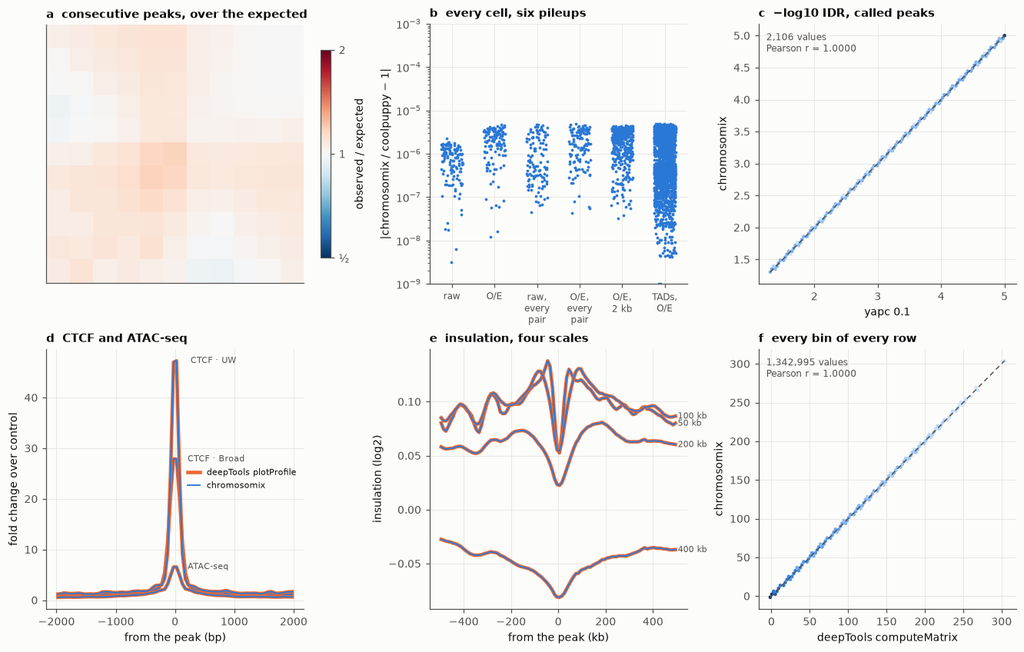

Figure 26: The rest of Fig. 2’s chain on GM12878, chr19. a, the pileup over consecutive CTCF peaks, every pair, over the expected, as chromosomix draws it; b, every cell of the six pileups against coolpuppy’s, the last two Fig. 2’s own at 2 kb, its consecutive peaks and its TADs; c, −log10 IDR of every peak both call at IDR ≤ 0.05; d, CTCF’s two tracks and ATAC-seq about the peaks; e, the insulation at its four scales about them; f, every cell of both metaplots’ heatmaps against computeMatrix’s.

```python
TEXT['gm_pairs'] = f'{len(gm_pairs):,}'
TEXT['gm_apa_rel'] = f'{max(v.max() for v in gm_cut_rel.values()):.1e}'
TEXT['gm_edge'] = f'{gm_edge[2000]:,}'
TEXT['gm_tads'] = f"{len(pd.read_csv(GM_DOMAINS, sep='\t', header=None)):,}"
GM_APA_GAPS = all(gm_same_gaps.values())
TEXT['gm_apa_gaps'] = 'the same cells left as gaps' if GM_APA_GAPS else 'different cells left as gaps'
TEXT['gm_peaks'] = f'{len(gm_called):,}'
TEXT['gm_peaks_same'] = f'{len(gm_same_called):,}'
TEXT['gm_idr'] = f'{max(gm_idr_app):.1e}'
TEXT['gm_idr_self'] = f'{max(gm_idr_self):.1e}'
GM_IDR_WITHIN = max(gm_idr_app) <= max(gm_idr_self) + 1e-5
GM_PEAKS_SAME = len(gm_same_called) == len(gm_called) == len(gm_called_ref) and gm_counts_agree
TEXT['gm_mp_profile'] = f"{max(v['profile'] for v in gm_plot.values()):.1e}"
TEXT['gm_mp_past'] = f"{sum(v['past'] for v in gm_plot.values()):,}"
TEXT['gm_mp_sites'] = f"{gm_plot['signal']['rows']:,}"
GM_METAPLOT_OK = all(v['past'] == 0 and v['one_to_one'] and v['order'] for v in gm_plot.values())

fig, axes = plt.subplots(2, 3, figsize=(12, 7.6), layout='constrained')
ax = axes[0, 0]
grey_gm = plt.get_cmap('RdBu_r').copy()
grey_gm.set_bad(MISSING)
bar = square(ax, gm_cut_app['oe-every'], 'a  consecutive peaks, over the expected', cmap=grey_gm,
             norm=LogNorm(1 / 2, 2), label='observed / expected')
bar.set_ticks([1 / 2, 1, 2], labels=['½', '1', '2'])
bar.minorticks_off()
ax = axes[0, 1]
for k, cut_key in enumerate(GM_PILEUPS):
    values = np.maximum(gm_cut_rel[cut_key], 1e-9)
    ax.scatter(k + np.linspace(-0.25, 0.25, values.size), values, s=6, color=APP_COLOUR, lw=0, gid=GM_PILEUPS[cut_key])
ax.set(yscale='log', ylim=(1e-9, 1e-3), ylabel='|chromosomix / coolpuppy − 1|', title='b  every cell, six pileups')
ax.set_xticks(range(len(GM_PILEUPS)),
              ['raw', 'O/E', 'raw,\nevery\npair', 'O/E,\nevery\npair', 'O/E,\n2 kb', 'TADs,\nO/E'], fontsize=8)
agreement(axes[0, 2], gm_idr['cond_globalIDR'].to_numpy(float), gm_idr['score'].to_numpy(float), 'yapc 0.1',
          'chromosomix', 'c  −log10 IDR, called peaks')
names_signal = ['CTCF · Broad', 'CTCF · UW', 'ATAC-seq']
for ax, plot_key, names_, unit in ((axes[1, 0], 'signal', names_signal, 'from the peak (bp)'),
                                   (axes[1, 1], 'insulation', [f'{w * 10} kb' for w in GM_WINDOWS], 'from the peak (kb)')):
    v = gm_plot[plot_key]
    x = v['offsets'] / (1e3 if plot_key == 'insulation' else 1)
    for i, (mine_, theirs_, name_) in enumerate(zip(v['mine'], v['theirs'], names_)):
        ax.plot(x, theirs_, color=REF, lw=3, label='deepTools plotProfile' if i == 0 else None,
                gid=f'deepTools plotProfile, {name_}')
        ax.plot(x, mine_, color=APP_COLOUR, lw=1.2, label='chromosomix' if i == 0 else None, gid=f'chromosomix, {name_}')
        # The signal's three curves meet at their ends and part at the peak: each is named beside its summit.
        at = int(np.nanargmax(mine_)) if plot_key == 'signal' else -1
        ax.annotate(name_, (x[at], mine_[at]), xytext=(12 if plot_key == 'signal' else 2, 0),
                    textcoords='offset points', fontsize=7, color=INK2, va='center')
    ax.set(xlabel=unit, ylabel='fold change over control' if plot_key == 'signal' else 'insulation (log2)',
           title='d  CTCF and ATAC-seq' if plot_key == 'signal' else 'e  insulation, four scales')
# One key for both, where d has room for it.
axes[1, 0].legend(loc='center right', fontsize=7, handlelength=1.5)
agreement(axes[1, 2], np.r_[gm_plot['signal']['heat_theirs'], gm_plot['insulation']['heat_theirs']],
          np.r_[gm_plot['signal']['heat_mine'], gm_plot['insulation']['heat_mine']], 'deepTools computeMatrix',
          'chromosomix', 'f  every bin of every row')
drawn('fig-gm-fig2')
```

The chain agrees link by link. The same 2,106 of the 2,106 CTCF peaks pass IDR ≤ 0.05 in both, their −log10 IDR within 1.9e-05 of every yapc run, whose seeds differ from one another by up to 2.3e-05. Over the 2,105 pairs of consecutive peaks the five pileups draw the same cells left as gaps and every other cell within 4.9e-06 of coolpuppy’s — Fig. 2’s at 2 kb too, where 1 of the peaks has its midpoint half a base before a bin edge and both tools round it down — and so do the 305 TADs between the boundaries, stretched evenly over the expected. About the 2,106 peaks, every profile is within 4.8e-06 of `plotProfile`‘s, and 0 cells of the heatmaps lie past the two tools’ rounding.

```python
GM_OK = (max(d.max() for d in gm_diff.values()) < 1e-5 and int((gm_calls['_merge'] != 'both').sum()) == 0
         and GM_PEAKS_SAME and GM_APA_GAPS and max(v.max() for v in gm_cut_rel.values()) < 1e-5 and GM_METAPLOT_OK)
record(GM_ANALYSIS, 'GM12878 Hi-C, 10 and 2 kb; CTCF ChIP-seq of two labs and ATAC-seq; chr19',
       f"cooltools {VERSIONS['cooltools']}, yapc {YAPC}, coolpuppy {VERSIONS['coolpuppy']}, deepTools {VERSIONS['deeptools']}",
       f"insulation at four scales within {TEXT['gm_ins_max']}, the same {TEXT['gm_calls']} boundaries; "
       f"the same {TEXT['gm_peaks_same']} peaks at IDR ≤ 0.05, −log10 IDR within {TEXT['gm_idr']} "
       f"(seeds among themselves: up to {TEXT['gm_idr_self']}); APA over {TEXT['gm_pairs']} consecutive pairs within "
       f"{TEXT['gm_apa_rel']}; metaplots within {TEXT['gm_mp_profile']}, {TEXT['gm_mp_past']} cells past the rounding",
       ('Identical (float32)' + ('; IDR within yapc\'s seed-to-seed spread' if GM_IDR_WITHIN else '')) if GM_OK
       else 'Differs',
       apps=[name for name, app in APP.items() if app['analysis'] == GM_ANALYSIS],
       refs=[name for name, ref in REFS.items() if ref['analysis'] == GM_ANALYSIS])
```

## 25 · Pairs statistics (pairtools)

What `pairtools stats` counts over a contact list — records mapped on both sides, on one and on neither, duplicates, cis and trans and cis past 1 to 40 kb, every pair type, the four strand orientations by separation and where they converge, and the library’s size — counted by the pass the app’s import makes of a `.pairs` file, through `chromosomix stats`, against `pairtools stats` itself. The library is a yeast Hi-C contact list as pairtools wrote it, deduplicated, each pair with its type and its two SAM records. pairtools has an environment of its own, on Python 3.12: 1.1.2 imports the `pipes` module 3.13 removed.

|  | chromosomix | pairtools |
| --- | --- | --- |
| command | `stats` | `stats` |
| compared | every key pairtools writes, and its value as the file spells it |  |

```python
PS = WORK / 'pairstats'
PS.mkdir(parents=True, exist_ok=True)
mr('stats', CH128, out=PS / 'app', name='pairstats', analysis='Pairs statistics')
reference('pairtools-stats', 'Pairs statistics', 'pairtools', [PAIRTOOLS, 'stats', CH128, '-o', OUT],
          out=PS / 'pairtools.stats', env=PAIRTOOLS_ENV)


def stats_file(path):
    """A `.stats` file as pairtools reads one back: a key and a value a line."""
    with open(path) as handle:
        return dict(line.rstrip('\n').split('\t', 1) for line in handle if line.strip())


ours, theirs = stats_file(one(PS / 'app', '*.stats')), stats_file(PS / 'pairtools.stats')
only = sorted(set(ours) ^ set(theirs))
differ = {key: (ours.get(key), value) for key, value in theirs.items() if ours.get(key) != value}
STRANDS = ['++', '--', '-+', '+-']
#: The separation bins' left edges, as pairtools' keys name them: `dist_freq/<lo>-<hi>/<strands>`, the
#: last `dist_freq/<lo>+/<strands>`.
edges = sorted({int(key.split('/')[1].split('-')[0].rstrip('+')) for key in theirs if key.startswith('dist_freq/')})
ranges = [f'{lo}-{hi}' for lo, hi in zip(edges, edges[1:])] + [f'{edges[-1]}+']


def binned(table, strands):
    """One orientation's cis pairs per separation bin, in the bins' order."""
    return np.array([int(table[f'dist_freq/{span}/{strands}']) for span in ranges])


TEXT['ps_records'] = f"{int(theirs['total']):,}"
TEXT['ps_keys'] = f'{len(theirs):,}'
TEXT['ps_same'] = 'every one of them spelled the same' if not differ and not only else \
    f'{len(differ)} spelled differently and {len(only)} in one file only'
TEXT['ps_types'] = ', '.join(key.split('/')[1] for key in theirs if key.startswith('pair_types/'))
TEXT['ps_cis'] = f"{float(theirs['summary/frac_cis']):.1%}"
TEXT['ps_meet'] = theirs['summary/dist_freq_convergence/convergence_dist']
display(measures({
    'records': TEXT['ps_records'],
    'keys, chromosomix / pairtools': f'{len(ours):,} / {len(theirs):,}',
    'keys in one file only': ', '.join(only) or 'none',
    'values spelled differently': ', '.join(f'{k}: {a} / {b}' for k, (a, b) in differ.items()) or 'none',
    'mapped, duplicates (pairtools)': f"{int(theirs['total_mapped']):,}, {int(theirs['total_dups']):,}",
    'cis, of the unique (pairtools)': TEXT['ps_cis'],
    'pair types': TEXT['ps_types'],
    'strands converge past (pairtools), bp': TEXT['ps_meet'],
    'library size (pairtools)': theirs['summary/complexity_naive'],
}))
```

```
$ chromosomix stats data/CH128.pairs.gz --out pairstats/app
$ pairtools stats data/CH128.pairs.gz -o pairstats/pairtools.stats
```

| measure | value |
| --- | --- |
| records | 17,583,821 |
| keys, chromosomix / pairtools | 509 / 509 |
| keys in one file only | none |
| values spelled differently | none |
| mapped, duplicates (pairtools) | 17,583,821, 0 |
| cis, of the unique (pairtools) | 97.1% |
| pair types | UU |
| strands converge past (pairtools), bp | 1778279 |
| library size (pairtools) | nan |

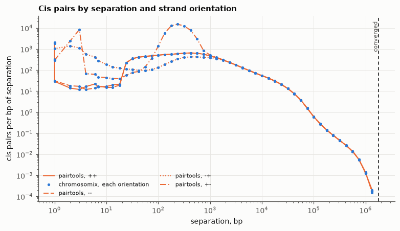

Figure 27: Cis pairs by separation in each of the four strand orientations, per base pair of each bin: pairtools’ (lines) and chromosomix’s (points), and the separation past which pairtools finds every orientation within 5 % of their mean.

```python
fig, ax = plt.subplots(figsize=(7, 4), layout='constrained')
# Each bin's width, the last as wide as an eighth of a decade past its edge; drawn from 1 bp, on a log axis.
widths = np.diff(np.r_[edges, edges[-1] * 10 ** (1 / 8)])
starts = np.maximum(edges, 1)
# An orientation a dash, pairtools' in orange and chromosomix's points over it in blue.
DASHES = {'++': '-', '--': (0, (5, 2)), '-+': (0, (1, 1.5)), '+-': (0, (6, 2, 1, 2))}
for strands in STRANDS:
    reference_curve, app_curve = binned(theirs, strands), binned(ours, strands)
    seen = reference_curve > 0
    ax.plot(starts[seen], (reference_curve / widths)[seen], color=REF, lw=1.3, ls=DASHES[strands],
            label=f'pairtools, {strands}')
    ax.plot(starts[seen], (app_curve / widths)[seen], ls='none', marker='o', ms=2.4, color=APP_COLOUR,
            label='chromosomix, each orientation' if strands == '++' else None, gid=f'chromosomix {strands}')
meet = theirs['summary/dist_freq_convergence/convergence_dist']
if meet != '0':
    ax.axvline(int(meet), color=INK, lw=1, ls=(0, (4, 3)), gid='convergence')
    ax.text(int(meet), 0.97, ' converged', transform=ax.get_xaxis_transform(), va='top', ha='right',
            fontsize=7, color=INK2, rotation=90)
ax.set(xscale='log', yscale='log', xlabel='separation, bp', ylabel='cis pairs per bp of separation',
       title='Cis pairs by separation and strand orientation')
ax.legend(ncol=2, fontsize=7)
drawn('fig-pairstats')
PAIRSTATS_SAME = not differ and not only
```

pairtools wrote 509 keys for the 17,583,821 pairs, and the app’s import counted every one of them spelled the same: the totals, the pair types (UU), the cis fraction of 97.1%, every separation bin of every orientation, and the convergence past 1778279 bp. A library with no duplicates has no estimate of its size, and both write `nan` for it: scipy’s Lambert W at `-exp(-1)`, which lies a hair past -1/e, and the port’s.

```python
record('Pairs statistics', 'yeast Hi-C contact list, deduplicated', f'pairtools {PAIRTOOLS_VERSION}',
       'every key, and every value as the file spells it',
       'Identical' if PAIRSTATS_SAME else 'Differs', apps=['pairstats'], refs=['pairtools-stats'])
```

## 26 · Restriction sites (bioframe)

Where an enzyme cuts a reference. `chromosomix restriction` finds the sites of DpnII (`^GATC`) along the yeast reference R64-1-1 and counts them in each bin of a 5 kb map; `bioframe.digest` finds them with Biopython’s `Bio.Restriction`. § 27 reads § 25’s contact list against these sites.

**The enzyme.** The enzyme CH128 was made with is not recorded. DpnII is chosen to check the computation, not the biology: § 27’s classes say what the library looks like if DpnII cut it, and nothing in the file says that it did. The reads themselves point to a GATC cutter (§ 27), but that is the reads’ evidence, not a record.

**The cut, 2 bp apart.** For a site whose first base is at s (0-based), cut k bases in (0 for `^GATC`), chromosomix cuts at c = s + k, the 0-based index of the first base after the cut, and a fragment runs from one cut to the next, [B<sub>i</sub>, B<sub>i+1</sub>). bioframe’s fragments end 2 bp later, at c + 2. Biopython’s `search` gives the 1-based position of the first base after the cut, c + 1, and `bioframe.digest` adds 1 to it (`np.array(cut_finder(seq)) + 1`), where converting it to 0-based would take 1 away. `cooler digest` is the same code, so a fragment BED from cooler or bioframe is 2 bp late, at every site of every enzyme. The check is therefore that bioframe’s boundaries are chromosomix’s cuts plus 2, every one. The fragments `pairtools restrict` is given are bioframe’s moved back by 2 (`bioframe_digest.py`’s SHIFT), chromosomix’s own, so that it puts ends on the boundaries the app puts them on — for the top strand; § 27 has the bottom strand’s.

|  | chromosomix | reference |
| --- | --- | --- |
| cuts | `restriction --enzyme DpnII`, its sites | `bioframe.digest(genome, 'DpnII')`, each boundary less 2 |
| cuts per bin | `restriction`, its density on the 5 kb map’s bins | the same cuts, counted per bin |

```python
import gzip

RS = WORK / 'restriction'
RS.mkdir(parents=True, exist_ok=True)
RS_ANALYSIS, PQ_ANALYSIS = 'Restriction sites', 'Pairs QC'
ENZYME, RS_BIN = 'DpnII', 5_000
#: R64-1-1 as one plain FASTA beside its index, by which bioframe reads it, and its sizes, by which cooler
#: bins: written once from the gzip Ensembl serves.
R64 = PATHS['R64-1-1']
R64_FA, R64_SIZES = DATA / 'R64-1-1.fa', DATA / 'R64-1-1.chrom.sizes'
if REDO or not R64_FA.exists():
    with gzip.open(R64, 'rt') as packed, open(R64_FA, 'w') as plain:
        shutil.copyfileobj(packed, plain)
    Path(f'{R64_FA}.fai').unlink(missing_ok=True)
pyfaidx.Faidx(str(R64_FA)).close()
R64_LENGTHS = pd.read_csv(f'{R64_FA}.fai', sep='\t', header=None, usecols=[0, 1], names=['chrom', 'length'])
if REDO or not R64_SIZES.exists():
    R64_LENGTHS.to_csv(R64_SIZES, sep='\t', header=False, index=False)


def pairs_sizes(path):
    """A contact list's `#chromsize:` lines: its sequences and their lengths, in its order."""
    sizes = {}
    with gzip.open(path, 'rt') as handle:
        for line in handle:
            if not line.startswith('#'):
                break
            if line.startswith('#chromsize:'):
                name, length = line.split()[1:3]
                sizes[name] = int(length)
    return sizes


CH128_SIZES = pairs_sizes(CH128)
R64_SAME = list(zip(R64_LENGTHS['chrom'], R64_LENGTHS['length'])) == list(CH128_SIZES.items())
if not R64_SAME:
    raise ValueError("R64-1-1's sequences are not the contact list's, by name, length and order.")
measures({'sequences, R64-1-1 and the contact list': f"{len(R64_LENGTHS)}: {', '.join(R64_LENGTHS['chrom'])}",
          'names, lengths and order': 'the same',
          'bases': f"{R64_LENGTHS['length'].sum():,}"})
```

| measure | value |
| --- | --- |
| sequences, R64-1-1 and the contact list | 17: I, II, III, IV, V, VI, VII, VIII, IX, X, XI, XII, XIII, XIV, XV, XVI, Mito |
| names, lengths and order | the same |
| bases | 12,157,105 |

The reference’s commands: the digest, and the 5 kb map `cooler cload pairs` bins from § 25’s contact list, whose bins the cuts are counted on. The map is also the binning Pairs QC does itself, and its coverage is § 27’s, so it is listed with § 27’s commands and timed against Pairs QC.

```python
reference('bioframe-digest', RS_ANALYSIS, 'bioframe, Biopython',
          [PYTHON, script('bioframe_digest'), R64_FA, ENZYME, RS_BIN, OUT, -2],
          out=RS / 'digest', made=RS / 'digest.sites.tsv')
# cooler's program, beside the interpreter pip put it with. Pairs QC's reference, made here for its bins.
reference('cooler-cload', PQ_ANALYSIS, 'cooler',
          ['cooler', 'cload', 'pairs', '-c1', 2, '-p1', 3, '-c2', 4, '-p2', 5, f'{rel(R64_SIZES)}:{RS_BIN}', CH128,
           OUT], out=RS / f'CH128.{RS_BIN}.cool',
          env={'PATH': f'{Path(PYTHON).parent}{os.pathsep}{os.environ["PATH"]}'})
```

```
$ python ../../scripts/bioframe_digest.py data/R64-1-1.fa DpnII 5000 restriction/digest -2
$ cooler cload pairs -c1 2 -p1 3 -c2 4 -p2 5 data/R64-1-1.chrom.sizes:5000 data/CH128.pairs.gz restriction/CH128.5000.cool
```

```
PosixPath('/home/runner/work/chromosomix/chromosomix/notebooks/work/validation/restriction/CH128.5000.cool')
```

chromosomix’s: the sites on that map, whose bins the density is counted on.

```python
mr('restriction', RS / f'CH128.{RS_BIN}.cool', '--sequence', R64_FA, '--enzyme', ENZYME, out=RS / 'app-sites',
   name='restriction', analysis=RS_ANALYSIS)
```

```
$ chromosomix restriction restriction/CH128.5000.cool --sequence data/R64-1-1.fa --enzyme DpnII --out restriction/app-sites
```

```
PosixPath('/home/runner/work/chromosomix/chromosomix/notebooks/work/validation/restriction/app-sites')
```

```python
#: Each output §§ 26 and 27 read, by where chromosomix writes it: `<map>.<task>.<output id>.<ext>`, as
#: `writeOutputs` (src/cli/main.ts) names its files. The readers below put each into the reference's shape;
#: this cell and § 27's are the only places an output's name or columns are spelled.
APP_OUT = {
    # The cuts, a point [c, c + 1) each, and their density on the map's bins: `restriction-<the enzyme>`.
    'cuts': (RS / 'app-sites', '*.restriction.restriction-*.bed'),
    'density': (RS / 'app-sites', '*.restriction.restriction-*-density.bedGraph'),
}


def app_out(key):
    return one(*APP_OUT[key])


def merged(app, path, on, value):
    """chromosomix's numbers beside the reference's, keyed, every key of either kept: a missing number is 0."""
    ref = pd.read_csv(path, sep='\t', dtype={'chrom': str})
    both = app.merge(ref, on=on, how='outer', suffixes=('_app', '_ref'))
    both[[f'{value}_app', f'{value}_ref']] = both[[f'{value}_app', f'{value}_ref']].fillna(0)
    return both


def app_cuts():
    """chromosomix's cuts, a row each (chrom, cut): the start of each point in the BED it writes."""
    return pd.read_csv(app_out('cuts'), sep='\t', comment='#', header=None, usecols=[0, 1], names=['chrom', 'cut'],
                       dtype={'chrom': str})


def app_density():
    """Its cuts per bin (chrom, start, end, sites), from the density's bedGraph."""
    return pd.read_csv(app_out('density'), sep='\t', comment='#', header=None, names=['chrom', 'start', 'end', 'sites'],
                       dtype={'chrom': str})
```

```python
rs_lengths = dict(zip(R64_LENGTHS['chrom'], R64_LENGTHS['length']))
# bioframe's boundaries between fragments, as it writes them: every end but each sequence's last.
rs_bioframe = pd.read_csv(RS / 'digest.bioframe.bed', sep='\t', header=None, names=['chrom', 'start', 'end'],
                          dtype={'chrom': str})
rs_bioframe = rs_bioframe[rs_bioframe['end'] != rs_bioframe['chrom'].map(rs_lengths)]
rs_app_cuts = app_cuts()


def offsets(app, bioframe):
    """bioframe's boundaries less chromosomix's cuts, sequence by sequence, the first less the first, the
    second less the second and so on — or, where the two find a different number, each cut's nearest."""
    out = []
    for chrom, ours in app.groupby('chrom'):
        theirs = np.sort(bioframe.loc[bioframe['chrom'] == chrom, 'end'].to_numpy())
        at = np.sort(ours['cut'].to_numpy())
        if len(theirs) == len(at):
            out.append(theirs - at)
            continue
        k = np.clip(np.searchsorted(theirs, at), 1, len(theirs) - 1)
        out.append(np.where(np.abs(theirs[k - 1] - at) <= np.abs(theirs[k] - at), theirs[k - 1], theirs[k]) - at)
    return np.concatenate(out)


rs_offsets = pd.Series(offsets(rs_app_cuts, rs_bioframe)).value_counts().sort_index()
rs_cut_match = rs_app_cuts.assign(end=rs_app_cuts['cut'] + 2).merge(rs_bioframe[['chrom', 'end']], how='outer',
                                                                    indicator=True)['_merge'].value_counts()
rs_density = merged(app_density(), RS / 'digest.sites.tsv', ['chrom', 'start', 'end'], 'sites')
CUTS_SAME = rs_cut_match.get('left_only', 0) == 0 and rs_cut_match.get('right_only', 0) == 0
DENSITY_SAME = bool((rs_density['sites_app'] == rs_density['sites_ref']).all())
measures({
    "cuts, chromosomix / bioframe's boundaries": f"{len(rs_app_cuts):,} / {len(rs_bioframe):,}",
    "bioframe's boundary less chromosomix's cut, in order": ', '.join(
        f'{k:+d} bp at {n:,}' for k, n in rs_offsets.items()),
    'cuts in one only, once 2 is added to chromosomix\'s': f"{rs_cut_match.get('left_only', 0):,} / "
                                                           f"{rs_cut_match.get('right_only', 0):,}",
    f'{RS_BIN // 1000} kb bins with the same cuts':
        f"{int((rs_density['sites_app'] == rs_density['sites_ref']).sum()):,} of {len(rs_density):,}",
})
```

| measure | value |
| --- | --- |
| cuts, chromosomix / bioframe's boundaries | 35,896 / 35,896 |
| bioframe's boundary less chromosomix's cut, in order | +2 bp at 35,896 |
| cuts in one only, once 2 is added to chromosomix's | 0 / 0 |
| 5 kb bins with the same cuts | 2,441 of 2,441 |

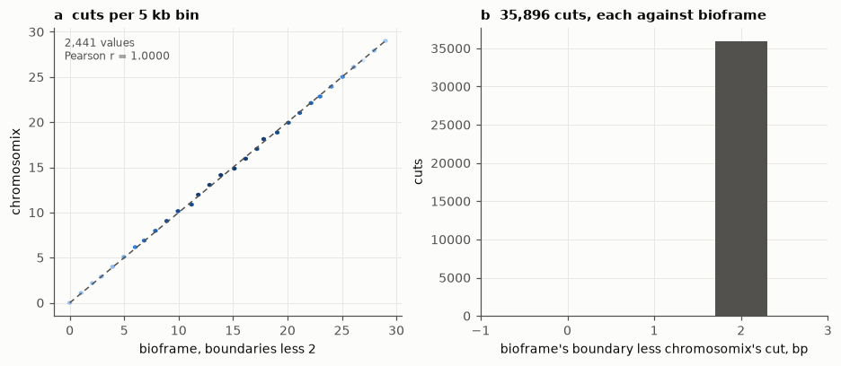

Figure 28: DpnII on R64-1-1, chromosomix against bioframe. a, cuts per 5 kb bin, bioframe’s boundaries less 2; b, bioframe’s boundary less chromosomix’s cut, at every cut.

```python
fig, axes = plt.subplots(1, 2, figsize=(8.4, 3.6), layout='constrained')
agreement(axes[0], rs_density['sites_ref'].to_numpy(float), rs_density['sites_app'].to_numpy(float),
          'bioframe, boundaries less 2', 'chromosomix', f'a  cuts per {RS_BIN // 1000} kb bin')
ax = axes[1]
ax.bar(rs_offsets.index, rs_offsets.to_numpy(), width=0.6, color=INK2, gid='cuts')
ax.set_xticks(range(min(-1, rs_offsets.index.min() - 1), max(4, rs_offsets.index.max() + 2)))
ax.set(xlabel="bioframe's boundary less chromosomix's cut, bp", ylabel='cuts',
       title=f'b  {len(rs_app_cuts):,} cuts, each against bioframe')
drawn('fig-restriction')
```

```python
RS_SAME = CUTS_SAME and set(rs_offsets.index) == {2} and DENSITY_SAME
TEXT['rs_cuts'] = f'{len(rs_bioframe):,}'
TEXT['rs_offset'] = ('each 2 bp past the app’s cut' if set(rs_offsets.index) == {2}
                     else 'at ' + ', '.join(f'{k:+d} bp from the app’s cut at {n:,}' for k, n in rs_offsets.items()))
TEXT['rs_bins'] = f'{len(rs_density):,}'
TEXT['rs_density'] = 'the same number of cuts in every one' if DENSITY_SAME else \
    f"different numbers in {int((rs_density['sites_app'] != rs_density['sites_ref']).sum()):,}"
```

bioframe finds the 35,896 sites chromosomix finds, each 2 bp past the app’s cut: bioframe’s `+ 1` on top of Biopython’s 1-based position. In the 2,441 bins of 5 kb the two count the same number of cuts in every one.

```python
record(RS_ANALYSIS, 'yeast R64-1-1, DpnII, 5 kb bins',
       f"bioframe {VERSIONS['bioframe']}, Biopython {VERSIONS['biopython']}",
       f"the same {TEXT['rs_cuts']} cuts, bioframe's 2 bp later; {TEXT['rs_density']} of the {TEXT['rs_bins']} bins",
       'Identical' if RS_SAME else 'Differs', apps=['restriction'], refs=['bioframe-digest'])
```

## 27 · Pairs QC (pairtools, cooltools)

What a contact list says about the fragments an enzyme cut. The restriction half of `chromosomix pairsqc` reads § 25’s contact list against § 26’s sites: the fragment each end lies in, the class of each pair, each end’s distance to the cut it reads towards, how many of the fragments the pairs reach, and each 5 kb bin’s coverage against its cuts. Its reference is three tools: `pairtools restrict`, which puts each end in a fragment; a short pandas script, `restriction_reference.py`, which counts from `pairtools restrict`’s columns by the definitions the task states (they are in the script’s docstring, below); and `cooltools.coverage`, over the same pairs binned by `cooler cload pairs` (§ 26). The rest of Pairs QC draws § 25’s counts. Its table of them is held to `pairtools stats` here too.

**An end’s fragment, by its own strand’s cut.** A `.pairs` position is the 1-based 5′ end of the read, x = pos − 1. Given a BED of fragments, pairtools puts it in fragment `searchsorted([0, end + 1, …], pos, 'right') − 1`, which is `searchsorted(B, x, 'right') − 1`: an end on a boundary lies in the fragment that starts there. That suits a read on the + strand, whose 5′ end is the top strand’s. A read on the − strand starts at the bottom strand’s 5′ end, and the bottom strand is cut elsewhere. DpnII cuts each strand before its own GATC. On the top strand’s coordinates that is before the G (c = s) and after the C (c′ = s + 4), a four-base overhang that the library’s fill-in makes double-stranded. So a fragment’s bottom strand runs to c′ − 1, where c′ = s + L − k is L − 2k bases past c; its last base is the site’s C. Placed by the top strand’s cuts, the − read of an unligated fragment lies 3 bp into the next fragment, and a dangling end counts as a re-ligation.

chromosomix therefore places a + end among the top strand’s boundaries, B = [0, …c, N], and a − end among the bottom strand’s, B′ = [0, …c′, N]. Fragment i is the same fragment in both. Each end’s distance is measured on its own strand’s boundaries: B[i+1] − x on +, x − B′[i] + 1 on −, so a dangling end’s two reads both give the fragment’s length. The reference does the same with pairtools. `pairtools restrict` runs twice, on the top strand’s fragments and on the bottom strand’s (bioframe’s boundaries moved by −2, and by −2 + L − 2k, which is +2 for DpnII), and the script reads each end’s fragment from the run on its strand. Everything counted below follows from where each end was put, so it checks chromosomix’s placement end by end.

|  | chromosomix | reference |
| --- | --- | --- |
| each end’s fragment | `pairsqc --enzyme DpnII` | `pairtools restrict` on each strand’s fragments, a + end read from the one and a − end from the other |
| classes, distances, fragments seen | `pairsqc` | `restriction_reference.py`, from `pairtools restrict`’s columns |
| coverage against cuts | `pairsqc --bin-size 5000` | § 26’s `cooler cload pairs` at 5 kb, `cooltools.coverage(ignore_diags=0)` less each bin’s diagonal (§ 9), SciPy’s `spearmanr` |
| the pairs’ statistics | `pairsqc`, its table | `pairtools stats` (§ 25’s) |

The reference’s commands: each end’s fragment and what is counted from it, and the coverage of § 26’s map. `pairtools stats` is § 25’s command and output; it is listed here again so that the timing weighs Pairs QC against every reference command it stands for, `cooler cload` among them.

```python
# Once on the top strand's fragments, for the + ends, and once on the bottom strand's, for the − ends.
for strand, suffix in (('top', ''), ('bottom', '-bottom')):
    reference(f'pairtools-restrict-{strand}', PQ_ANALYSIS, 'pairtools',
              [PAIRTOOLS, 'restrict', '-f', RS / f'digest.frags{suffix}.bed', CH128, '-o', OUT],
              out=RS / f'CH128.restricted{suffix}.pairs.gz', env=PAIRTOOLS_ENV)
reference('restriction-reference', PQ_ANALYSIS, 'pandas',
          [PYTHON, script('restriction_reference'), R64_FA, ENZYME, RS / 'CH128.restricted.pairs.gz',
           RS / 'CH128.restricted-bottom.pairs.gz', OUT, -2],
          out=RS / 'pairtools', made=RS / 'pairtools.summary.tsv')
reference('cooltools-coverage-sites', PQ_ANALYSIS, 'cooltools',
          [PYTHON, script('cooltools_coverage_sites'), RS / f'CH128.{RS_BIN}.cool', RS / 'digest.sites.tsv', OUT,
           THREADS], out=RS / 'coverage', made=RS / 'coverage.summary.tsv', threads=THREADS)
reference('pairsqc-pairtools-stats', PQ_ANALYSIS, 'pairtools', [PAIRTOOLS, 'stats', CH128, '-o', OUT],
          out=PS / 'pairtools.stats', env=PAIRTOOLS_ENV)
```

```
$ pairtools restrict -f restriction/digest.frags.bed data/CH128.pairs.gz -o restriction/CH128.restricted.pairs.gz
$ pairtools restrict -f restriction/digest.frags-bottom.bed data/CH128.pairs.gz -o restriction/CH128.restricted-bottom.pairs.gz
$ python ../../scripts/restriction_reference.py data/R64-1-1.fa DpnII restriction/CH128.restricted.pairs.gz restriction/CH128.restricted-bottom.pairs.gz restriction/pairtools -2
$ python ../../scripts/cooltools_coverage_sites.py restriction/CH128.5000.cool restriction/digest.sites.tsv restriction/coverage 4
$ pairtools stats data/CH128.pairs.gz -o pairstats/pairtools.stats
```

```
PosixPath('/home/runner/work/chromosomix/chromosomix/notebooks/work/validation/pairstats/pairtools.stats')
```

chromosomix’s: Pairs QC on the contact list itself, binned at the same 5 kb.

```python
mr('pairsqc', CH128, '--bin-size', RS_BIN, '--sequence', R64_FA, '--enzyme', ENZYME, out=RS / 'app-pairsqc',
   name='pairsqc', analysis=PQ_ANALYSIS)
```

```
$ chromosomix pairsqc data/CH128.pairs.gz --bin-size 5000 --sequence data/R64-1-1.fa --enzyme DpnII --out restriction/app-pairsqc
```

```
PosixPath('/home/runner/work/chromosomix/chromosomix/notebooks/work/validation/restriction/app-pairsqc')
```

```python
#: Pairs QC's outputs, each written as a TSV, read as § 26's cell reads the cuts.
RS_CLASSES = ['trans', 'dangling', 'self-circle', 'same-strand', 're-ligation', 'valid']
RS_ORIENTATIONS = ['++', '+-', '-+', '--']
APP_OUT.update({
    'classes': (RS / 'app-pairsqc', '*.pairsqc.pairsqc-classes-table.tsv'),
    'distance': (RS / 'app-pairsqc', '*.pairsqc.pairsqc-distance.tsv'),
    'fragments': (RS / 'app-pairsqc', '*.pairsqc.pairsqc-fragments.tsv'),
    'sites': (RS / 'app-pairsqc', '*.pairsqc.pairsqc-sites.tsv'),
    'stats': (RS / 'app-pairsqc', '*.pairsqc.pairsqc-stats.tsv'),
})


def ascii_minus(names):
    """Strands as the reference spells them, should a figure's − have reached a column's name."""
    return [str(n).replace('\u2212', '-') for n in names]


def app_classes():
    """Its pairs per class and orientation (class, orientation, pairs), from its table of the classes: a row a
    class, its pairs and share, and a column an orientation."""
    held = table(app_out('classes'))
    held.columns = ascii_minus(held.columns)
    return held[['class', *RS_ORIENTATIONS]].melt(id_vars='class', var_name='orientation', value_name='pairs')


def app_distance():
    """Its ends per distance bin and strand (strand, start, ends): a curve, each bin at its left edge, a column
    a strand."""
    held = table(app_out('distance'))
    held.columns = ['start', *ascii_minus(held.columns[1:])]
    return held.melt(id_vars='start', value_vars=['+', '-'], var_name='strand', value_name='ends')


def app_fragments():
    """Its fragments per number of ends (label, fragments): a bar a range, named as the range."""
    return table(app_out('fragments')).set_axis(['label', 'fragments'], axis=1)


def app_seen():
    """The fragments seen and of how many, as the fragments' label says: `… · seen / total fragments seen`."""
    with open(app_out('fragments')) as handle:
        label = next(line for line in handle if line.startswith('# output:'))
    return [int(n.replace(',', '')) for n in re.search(r'([\d,]+)\s*/\s*([\d,]+)', label).groups()]


def app_sites():
    """Its points, a bin each (sites, coverage), in its order — by sites, then along the genome — and its mean
    line (sites, coverage), one row per number of sites: a curve whose two series share the points' x."""
    held = table(app_out('sites')).set_axis(['sites', 'coverage', 'mean'], axis=1)
    # A number of cuts too few bins share has its points and no mean: the column is blank there.
    return (held[['sites', 'coverage']],
            held[['sites', 'mean']].dropna(subset=['mean']).drop_duplicates('sites')
            .rename(columns={'mean': 'coverage'}))


def app_rho():
    """Spearman's ρ as Pairs QC writes it in its note, as written."""
    for line in NOTES['pairsqc']:
        found = re.search(r'ρ\s*=\s*(-?[\d.]+)', line)
        if found:
            return found.group(1)
    raise ValueError(f'no note of pairsqc gives ρ: {NOTES["pairsqc"]}')


def app_stats():
    """Its table of the pairs' statistics: pairtools' key, and the value as written."""
    held = pd.read_csv(app_out('stats'), sep='\t', comment='#', dtype=str, keep_default_na=False)
    return dict(zip(held['statistic'], held['value']))
```

```python
rs_summary = pd.read_csv(RS / 'pairtools.summary.tsv', sep='\t').set_index('measure')['value']
rs_orientation = merged(app_classes(), RS / 'pairtools.orientation.tsv', ['class', 'orientation'], 'pairs')
rs_distance = merged(app_distance(), RS / 'pairtools.distance.tsv', ['strand', 'start'], 'ends')
rs_fragments = merged(app_fragments(), RS / 'pairtools.fragments.tsv', ['label'], 'fragments')
# The bins kept, in the order chromosomix writes its points: by their cuts, then along the genome.
rs_kept = pd.read_csv(RS / 'coverage.coverage.tsv', sep='\t', dtype={'chrom': str})
rs_kept = rs_kept[(rs_kept['coverage'] > 0) | (rs_kept['sites'] > 0)].sort_values('sites', kind='stable')
app_bins, app_means = app_sites()
rs_coverage = pd.concat([rs_kept[['chrom', 'start', 'sites', 'coverage']].reset_index(drop=True).add_suffix('_ref'),
                         app_bins.reset_index(drop=True).add_suffix('_app')], axis=1)
# Pairs QC draws the mean only where at least this many bins share a number of cuts, so a repeat's one
# bright bin does not draw the line; the reference's means are held to the same bins.
MEAN_MIN_BINS = 5
rs_means_ref = pd.read_csv(RS / 'coverage.means.tsv', sep='\t')
rs_means = (app_means.merge(rs_means_ref.loc[rs_means_ref['bins'] >= MEAN_MIN_BINS, ['sites', 'coverage']],
                            on='sites', how='outer', suffixes=('_app', '_ref')).fillna(0))
rs_cov_summary = pd.read_csv(RS / 'coverage.summary.tsv', sep='\t').set_index('measure')['value']
RHO_REF, RHO_APP = float(rs_cov_summary['spearman']), app_rho()
SEEN_APP, TOTAL_APP = app_seen()
rs_stats_app, rs_stats_ref = app_stats(), stats_file(PS / 'pairtools.stats')
rs_stats_differ = {k: (v, rs_stats_ref.get(k)) for k, v in rs_stats_app.items() if rs_stats_ref.get(k) != v}


def same(frame, value):
    return int((frame[f'{value}_app'] != frame[f'{value}_ref']).sum())


RS_HELD = {
    'classes by orientation': same(rs_orientation, 'pairs'),
    'distance bins, both strands': same(rs_distance, 'ends'),
    'fragments per number of ends': same(rs_fragments, 'fragments'),
    f'{RS_BIN // 1000} kb bins kept, in order: coverage': same(rs_coverage, 'coverage'),
    f'{RS_BIN // 1000} kb bins kept, in order: cuts': same(rs_coverage, 'sites'),
}
RS_MEANS_GAP = float(relative_difference(rs_means['coverage_app'].to_numpy(float),
                                         rs_means['coverage_ref'].to_numpy(float)).max())
RS_RHO_GAP = abs(float(RHO_APP) - RHO_REF)
RS_RHO_NEAR = rounded(len(RHO_APP.split('.')[-1]))
measures({
    'pairs counted (pairtools restrict, pandas)': f"{int(rs_summary['counted']):,} of {int(rs_summary['records']):,}",
    "ends pairtools puts on fragments other than the digest's": f"{int(rs_summary['ends off the digest']):,}",
    **{f'{name}, differing': f'{n:,}' for name, n in RS_HELD.items()},
    'fragments seen, chromosomix / pandas':
        f"{SEEN_APP:,} of {TOTAL_APP:,} / {int(rs_summary['fragments seen']):,} of {int(rs_summary['fragments']):,}",
    'mean coverage per number of cuts, max relative difference': f'{RS_MEANS_GAP:.1e}',
    "Spearman's ρ, chromosomix (as written) / SciPy": f'{RHO_APP} / {RHO_REF:.6f}',
    'statistics in its table, written as pairtools writes them':
        f"{len(rs_stats_app) - len(rs_stats_differ):,} of {len(rs_stats_app):,}",
})
```

| measure | value |
| --- | --- |
| pairs counted (pairtools restrict, pandas) | 17,583,821 of 17,583,821 |
| ends pairtools puts on fragments other than the digest's | 0 |
| classes by orientation, differing | 0 |
| distance bins, both strands, differing | 0 |
| fragments per number of ends, differing | 0 |
| 5 kb bins kept, in order: coverage, differing | 0 |
| 5 kb bins kept, in order: cuts, differing | 0 |
| fragments seen, chromosomix / pandas | 34,289 of 35,913 / 34,289 of 35,913 |
| mean coverage per number of cuts, max relative difference | 3.9e-06 |
| Spearman's ρ, chromosomix (as written) / SciPy | 0.482 / 0.482321 |
| statistics in its table, written as pairtools writes them | 51 of 51 |

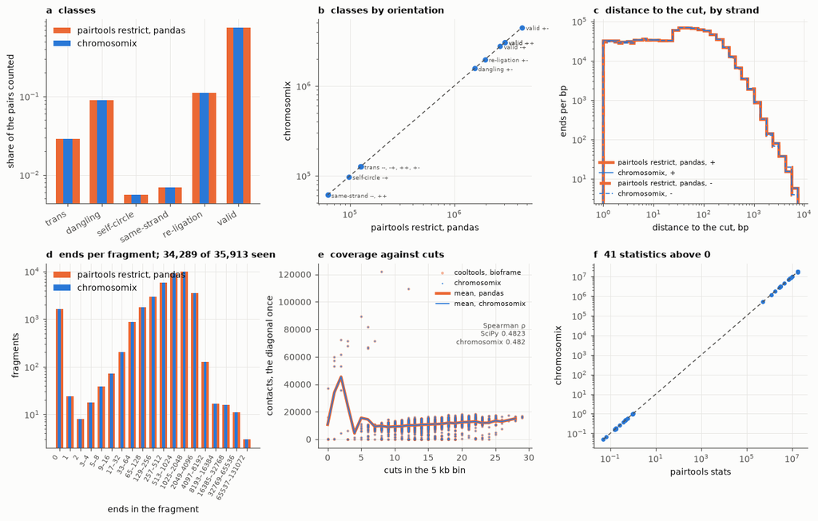

Figure 29: The contact list’s pairs against § 26’s DpnII sites: pairtools restrict, pandas, pairtools stats and cooltools (orange) and chromosomix (blue). a, the pairs in each class, of those counted; b, each class in each orientation; c, the distance from each end to the cut it reads towards, per bp of each bin, on each strand; d, the fragments with each number of ends; e, each 5 kb bin’s coverage against its cuts, and the mean coverage per number of cuts; f, the statistics in Pairs QC’s table against pairtools stats’, each above 0.

```python
rs_classes = rs_orientation.groupby('class', sort=False)[['pairs_app', 'pairs_ref']].sum().reindex(RS_CLASSES)
rs_counted = int(rs_summary['counted'])
# Every closed bin from 1 bp, no end being 0 from its cut, to the last any end is in on either strand.
rs_reached = rs_distance.loc[(rs_distance[['ends_app', 'ends_ref']] > 0).any(axis=1), 'start'].max()
rs_closed = rs_distance[rs_distance['end'].notna() & rs_distance['start'].between(1, rs_reached)].sort_values(
    ['strand', 'start'])
rs_frag_order = pd.read_csv(RS / 'pairtools.fragments.tsv', sep='\t')['label']
rs_frag_bars = rs_fragments.set_index('label').reindex(rs_frag_order).fillna(0)
RS_DASH = {'+': '-', '-': (0, (4, 2))}

fig, axes = plt.subplots(2, 3, figsize=(12, 7.6), layout='constrained')
ax = axes[0, 0]
at = np.arange(len(RS_CLASSES))
ax.bar(at, rs_classes['pairs_ref'] / rs_counted, width=0.7, color=REF, label='pairtools restrict, pandas')
ax.bar(at, rs_classes['pairs_app'] / rs_counted, width=0.28, color=APP_COLOUR, label='chromosomix')
ax.set_xticks(at, RS_CLASSES, rotation=30, ha='right')
ax.set(yscale='log', ylabel='share of the pairs counted', title='a  classes')
ax.legend(loc='upper left')
ax = axes[0, 1]
shown = rs_orientation[(rs_orientation['pairs_ref'] > 0) | (rs_orientation['pairs_app'] > 0)]
ax.scatter(shown['pairs_ref'], shown['pairs_app'], s=22, color=APP_COLOUR, zorder=3, gid='class and orientation')
identity(ax, shown[['pairs_ref', 'pairs_app']].min().min(), shown[['pairs_ref', 'pairs_app']].max().max())
# A name a point, those of a class within 2 % of one another named once.
for name, rows in shown.sort_values('pairs_ref').groupby(['class', np.round(np.log10(shown['pairs_ref']) / 0.01)],
                                                         sort=False):
    ax.annotate(f"{name[0]} {', '.join(rows['orientation'])}", (rows['pairs_ref'].iloc[0], rows['pairs_app'].iloc[0]),
                fontsize=6, color=INK2, xytext=(4, -3), textcoords='offset points')
ax.set(xscale='log', yscale='log', xlabel='pairtools restrict, pandas', ylabel='chromosomix',
       title='b  classes by orientation')
ax = axes[0, 2]
for strand, rows in rs_closed.groupby('strand'):
    edges_ = np.r_[rows['start'].to_numpy(float), rows['end'].to_numpy(float)[-1]]
    width = np.diff(edges_)
    ax.stairs(rows['ends_ref'] / width, edges_, color=REF, lw=3, ls=RS_DASH[strand],
              label=f'pairtools restrict, pandas, {strand}')
    ax.stairs(rows['ends_app'] / width, edges_, color=APP_COLOUR, lw=1.1, ls=RS_DASH[strand],
              label=f'chromosomix, {strand}')
ax.set(xscale='log', yscale='log', xlabel='distance to the cut, bp', ylabel='ends per bp',
       title='c  distance to the cut, by strand')
ax.legend(loc='lower left', fontsize=7)
ax = axes[1, 0]
at = np.arange(len(rs_frag_bars))
ax.bar(at, rs_frag_bars['fragments_ref'], width=0.7, color=REF, label='pairtools restrict, pandas')
ax.bar(at, rs_frag_bars['fragments_app'], width=0.28, color=APP_COLOUR, label='chromosomix')
ax.set_xticks(at, rs_frag_bars.index, rotation=60, ha='right', fontsize=7)
ax.set(yscale='log', xlabel='ends in the fragment', ylabel='fragments',
       title=f"d  ends per fragment; {int(rs_summary['fragments seen']):,} of {int(rs_summary['fragments']):,} seen")
ax.legend(loc='upper left')
ax = axes[1, 1]
ax.scatter(rs_coverage['sites_ref'], rs_coverage['coverage_ref'], s=9, color=REF, alpha=0.5, lw=0,
           label='cooltools, bioframe')
ax.scatter(rs_coverage['sites_app'], rs_coverage['coverage_app'], s=2, color=APP_COLOUR, lw=0, label='chromosomix')
ax.plot(rs_means['sites'], rs_means['coverage_ref'], color=REF, lw=3, label='mean, pandas')
ax.plot(rs_means['sites'], rs_means['coverage_app'], color=APP_COLOUR, lw=1.1, label='mean, chromosomix')
ax.text(0.97, 0.68, f'Spearman ρ\nSciPy {RHO_REF:.4f}\nchromosomix {RHO_APP}', transform=ax.transAxes,
        ha='right', va='top', fontsize=7, color=INK2)
ax.set(xlabel=f'cuts in the {RS_BIN // 1000} kb bin', ylabel='contacts, the diagonal once',
       title='e  coverage against cuts')
ax.legend(loc='upper right', fontsize=7)
ax = axes[1, 2]
# Its statistics written as numbers, each against pairtools stats', those above 0 on the log axes.
rs_stats_both = pd.DataFrame([(pd.to_numeric(rs_stats_ref[k], errors='coerce'), pd.to_numeric(v, errors='coerce'))
                              for k, v in rs_stats_app.items() if k in rs_stats_ref], columns=['ref', 'app'])
rs_stats_both = rs_stats_both[(rs_stats_both['ref'] > 0) & (rs_stats_both['app'] > 0)]
ax.scatter(rs_stats_both['ref'], rs_stats_both['app'], s=12, color=APP_COLOUR, zorder=3, gid='statistic')
identity(ax, rs_stats_both.min().min(), rs_stats_both.max().max())
ax.set(xscale='log', yscale='log', xlabel='pairtools stats', ylabel='chromosomix',
       title=f'f  {len(rs_stats_both):,} statistics above 0')
drawn('fig-pairsqc')
```

```python
PQ_SAME = (not any(RS_HELD.values()) and int(rs_summary['ends off the digest']) == 0
           and (SEEN_APP, TOTAL_APP) == (int(rs_summary['fragments seen']), int(rs_summary['fragments']))
           and RS_RHO_GAP <= RS_RHO_NEAR and RS_MEANS_GAP <= significant(6) and not rs_stats_differ)
rs_fraction = rs_classes['pairs_ref'] / rs_counted
TEXT['rs_counted'] = f'{rs_counted:,}'
TEXT['rs_held'] = ('the same, key for key' if not any(RS_HELD.values())
                   else '; '.join(f'{name}: {n:,} differ' for name, n in RS_HELD.items() if n))
TEXT['rs_seen'] = f"{int(rs_summary['fragments seen']):,}"
TEXT['rs_total'] = f"{int(rs_summary['fragments']):,}"
TEXT['rs_kept'] = f"{int(rs_cov_summary['kept']):,}"
TEXT['rs_rho'] = f'{RHO_REF:.4f}'
TEXT['rs_rho_app'] = RHO_APP
TEXT['rs_means'] = f'{RS_MEANS_GAP:.1e}'
TEXT['rs_stats'] = ('every one' if not rs_stats_differ
                   else f'all but {len(rs_stats_differ)} of the {len(rs_stats_app)}')
for name in RS_CLASSES:
    TEXT[f'rs_{name}'] = f'{rs_fraction[name]:.1%}'
# Reads that start where DpnII cut, on each strand, over those a base away.
TEXT['rs_plus'] = f"{rs_summary['+ ends on a cut'] / rs_summary['+ ends a base past a cut']:.0f}"
TEXT['rs_minus'] = f"{rs_summary['- ends on a cut'] / rs_summary['- ends a base before a cut']:.0f}"
# And the classes had every end been placed by the top strand's cuts.
rs_top_only = pd.read_csv(RS / 'pairtools.classes.tsv', sep='\t').set_index('class')['top_strand_only']
TEXT['rs_top_dangling'] = f"{rs_top_only['dangling'] / rs_counted:.1%}"
TEXT['rs_top_relig'] = f"{rs_top_only['re-ligation'] / rs_counted:.1%}"
```

Of the 17,583,821 pairs counted, the pandas script’s counts from `pairtools restrict`’s fragments and Pairs QC’s are the same, key for key: the six classes in their four orientations, every distance bin on both strands, the fragments with each number of ends (34,289 of 35,913 reached), and each bin’s coverage and cuts. The mean coverage at each number of cuts that at least five bins share — the only ones Pairs QC draws a mean for, so a repeat’s one bright bin does not draw the line — agrees within 3.9e-06, the six digits written. Over the 2,441 bins with coverage or a cut, Spearman’s ρ is 0.4823 by SciPy and 0.482 as chromosomix writes it, to three decimals. Of the statistics in Pairs QC’s table, every one is written as `pairtools stats` writes it.

```python
record(PQ_ANALYSIS, "§ 25's contact list against § 26's DpnII sites, 5 kb",
       f"pairtools {PAIRTOOLS_VERSION}, cooler {VERSIONS['cooler']}, cooltools {VERSIONS['cooltools']}",
       f"classes, distances, fragments seen and coverage {TEXT['rs_held']}; ρ {TEXT['rs_rho_app']} against "
       f"{TEXT['rs_rho']}; {TEXT['rs_stats']} of its statistics as pairtools writes it",
       'Identical' if PQ_SAME else 'Differs',
       apps=['pairsqc'],
       refs=['cooler-cload', 'pairtools-restrict-top', 'pairtools-restrict-bottom', 'restriction-reference',
             'cooltools-coverage-sites', 'pairsqc-pairtools-stats'])
```

## Summary

Commands as run, from `notebooks/work/validation/`: `chromosomix` is this checkout’s `node dist-cli/chromosomix.mjs`, `python` the reference packages’ interpreter, `yapc-env/bin/python` yapc’s. The reference scripts, in `notebooks/scripts/`, are listed below.

```python
WIDTHS = {'§': 3, 'Analysis': 8, 'Data': 9, 'chromosomix command': 24, 'Reference': 8, 'Reference command': 24,
          'Agreement': 13, 'Verdict': 11}
summary = pd.DataFrame(SUMMARY)[list(WIDTHS)]
# Every verdict as a table of its own, published beside the page (.github/workflows/notebooks.yml).
VERDICTS_TSV = WORK / 'summary.tsv'
summary.drop(columns=['chromosomix command', 'Reference command']).replace(r'<[^>]+>', '', regex=True).to_csv(
    VERDICTS_TSV, sep='\t', index=False)
# And every number the figures draw, a row a mark (`drawn`), published beside it too: to ten significant
# digits, as many as chromosomix writes its finest table to (`boost`) and more than any figure shows.
DRAWN_TXT = WORK / 'validation.txt'
pd.concat(DRAWN.values(), ignore_index=True).to_csv(DRAWN_TXT, sep='\t', index=False, float_format='%.10g')
summary.style.hide(axis='index').set_table_styles([
    {'selector': '', 'props': [('table-layout', 'fixed'), ('width', '100%'), ('font-size', '0.85em')]},
    {'selector': 'td, th', 'props': [('vertical-align', 'top'), ('text-align', 'left')]},
    {'selector': 'td pre', 'props': [('font-size', '0.85em'), ('white-space', 'pre-wrap'), ('overflow-wrap', 'anywhere'),
                                     ('margin', '0'), ('padding', '0'), ('background', 'transparent')]},
    *[{'selector': f'th.col{i}', 'props': [('width', f'{w}%')]} for i, w in enumerate(WIDTHS.values())],
])
```

§

Analysis

Data

chromosomix command

Reference

Reference command

Agreement

Verdict

1

Diamond insulation

mouse Hi-C, 10 kb, window 100 kb

```
$ chromosomix insulation data/4DNFIOZ1TRUS.mcool::/resolutions/10000 --window 10 --out insulation/app
```

cooltools 0.7.1

```
$ python ../../scripts/cooltools_insulation.py data/4DNFIOZ1TRUS.mcool::/resolutions/10000 insulation/cooltools.tsv 4
```

max |difference| 5.1e-06 over 250,342 bins; the same 11,089 boundaries

Identical (float32)

2

Directionality index

mouse Hi-C, 50 kb, window 2 Mb

```
$ chromosomix di data/4DNFIOZ1TRUS.mcool::/resolutions/50000 --window 40 --out di/app
```

domaincaller 0.1.0

```
$ python ../../scripts/domaincaller_di.py data/4DNFIOZ1TRUS.mcool::/resolutions/50000 di/domaincaller.npy
```

max relative difference 5.0e-06 over 48,094 bins; every sign agrees

Identical (float32)

3

Compartments

mouse Hi-C, 100 kb, GC-phased

```
$ chromosomix compartments data/4DNFIOZ1TRUS.mcool::/resolutions/100000 --components 3 --phaseTrack compartments/gc.bedGraph --out compartments/app
```

cooltools 0.7.1

```
$ python ../../scripts/cooltools_eigs_cis.py data/4DNFIOZ1TRUS.mcool::/resolutions/100000 compartments/gc.tsv compartments/cooltools
```

E1 r ≥ 0.9985 on 20 chromosomes; eigenvalues within 0.57%; A/B ≥ 98.85%

Same eigenvectors

4

P(s)

yeast Micro-C 800 bp; mouse Hi-C 10 kb

```
$ chromosomix expected data/GSE151553_A364_merged.mcool::/resolutions/800 --quantity expected --scope file --out ps/yeast
$ chromosomix expected data/4DNFIOZ1TRUS.mcool::/resolutions/10000 --quantity expected --scope file --out ps/mouse
```

cooltools 0.7.1

```
$ python ../../scripts/cooltools_expected_cis.py data/GSE151553_A364_merged.mcool::/resolutions/800 ps/yeast-cooltools.tsv 4
$ python ../../scripts/cooltools_expected_cis.py data/4DNFIOZ1TRUS.mcool::/resolutions/10000 ps/mouse-cooltools.tsv 4
```

max relative difference 3.7e-06 over 153 points

Identical (float32)

5

Peak calling (yapc, IDR)

mouse ATAC-seq, 2 replicates, chr19

```
$ chromosomix peaks --signal data/4DNFIIY4QW2D.chr19.bw --replicate data/4DNFITBRHVZE.chr19.bw --perPeak --width 150 --times 3 --minWidth 75 --truncate 100000 --idr 0.05 --out yapc/app
```

yapc 0.1, idr 2.0.3

```
$ yapc-env/bin/python ../../scripts/yapc_idr.py 0 yapc/seed0/yapc cond data/4DNFIIY4QW2D.chr19.bw data/4DNFITBRHVZE.chr19.bw --smoothing-window-width 150 --smoothing-times 3 --min-concave-region-width 75 --truncate-idr-input 100000
$ yapc-env/bin/python ../../scripts/yapc_idr.py 1 yapc/seed1/yapc cond data/4DNFIIY4QW2D.chr19.bw data/4DNFITBRHVZE.chr19.bw --smoothing-window-width 150 --smoothing-times 3 --min-concave-region-width 75 --truncate-idr-input 100000
$ yapc-env/bin/python ../../scripts/yapc_idr.py 2 yapc/seed2/yapc cond data/4DNFIIY4QW2D.chr19.bw data/4DNFITBRHVZE.chr19.bw --smoothing-window-width 150 --smoothing-times 3 --min-concave-region-width 75 --truncate-idr-input 100000
$ yapc-env/bin/python ../../scripts/yapc_idr.py 3 yapc/seed3/yapc cond data/4DNFIIY4QW2D.chr19.bw data/4DNFITBRHVZE.chr19.bw --smoothing-window-width 150 --smoothing-times 3 --min-concave-region-width 75 --truncate-idr-input 100000
$ yapc-env/bin/python ../../scripts/yapc_idr.py 4 yapc/seed4/yapc cond data/4DNFIIY4QW2D.chr19.bw data/4DNFITBRHVZE.chr19.bw --smoothing-window-width 150 --smoothing-times 3 --min-concave-region-width 75 --truncate-idr-input 100000
```

100,000 regions, same bounds and summits; 5,666 peaks at IDR ≤ 0.05; −log10 IDR within 8.7e-04 of 5 yapc seeds (seeds among themselves: up to 8.7e-04)

Identical peaks; IDR within yapc's seed-to-seed spread

6

Loops (chromosight)

yeast Micro-C, 800 bp

```
$ chromosomix chromosight data/GSE151553_A364_merged.mcool::/resolutions/800 --pattern loops --out loops/app
```

chromosight 1.6.3

```
$ chromosight detect --pattern loops --threads 4 data/GSE151553_A364_merged.mcool::/resolutions/800 loops/chromosight/loops
```

659 loops, the same bin pairs; scores within 5.1e-07

Identical

7

Reproducibility (HiCRep)

chicken Hi-C, 3 maps, 100 kb, raw counts

```
$ chromosomix hicrep data/4DNFIH8L6WON.mcool::/resolutions/100000 --against data/4DNFITBCUX56.mcool::/resolutions/100000 --against data/4DNFIIML46E5.mcool::/resolutions/100000 --maxDistance 50 --smooth 1 --no-balance --sequences chr1,chr2,chr3,chr4,chr5,chr6,chr7,chr8,chr9,chr10,chr11,chr12,chr13,ch…
```

hicrep 0.2.6

```
$ python ../../scripts/hicrep_scc.py hicrep/hicrep.tsv chr1,chr2,chr3,chr4,chr5,chr6,chr7,chr8,chr9,chr10,chr11,chr12,chr13,chr14,chr15,chr17,chr18,chr19,chr20,chr21,chr23,chr24,chr26,chr27,chrW,chrZ 4DNFIH8L6WON=data/4DNFIH8L6WON.mcool::/resolutions/100000 4DNFITBCUX56=data/4DNFITBCUX56.mcool::/res…
```

within 5.0e-05 over 78 values (4 decimals written)

Identical

8

3D model (pastis-NB)

yeast Micro-C, 12.8 kb, 905 beads

```
$ chromosomix reconstruct3d data/GSE151553_A364_merged.mcool::/resolutions/12800 --method nb --alpha 3 --seed 0 --out pastis/app-seed0
$ chromosomix reconstruct3d data/GSE151553_A364_merged.mcool::/resolutions/12800 --method nb --alpha 3 --seed 1 --out pastis/app-seed1
$ chromosomix reconstruct3d data/GSE151553_A364_merged.mcool::/resolutions/12800 --method nb --alpha 3 --seed 2 --out pastis/app-seed2
```

pastis 0.5.0 (GitHub 6888ac2)

```
$ python ../../scripts/pastis_nb.py data/GSE151553_A364_merged.mcool::/resolutions/12800 pastis/pastis-seed0.npy 0
$ python ../../scripts/pastis_nb.py data/GSE151553_A364_merged.mcool::/resolutions/12800 pastis/pastis-seed1.npy 1
$ python ../../scripts/pastis_nb.py data/GSE151553_A364_merged.mcool::/resolutions/12800 pastis/pastis-seed2.npy 2
```

same seed: within chromosomes ρ = 0.978–0.993, between 0.90–1.00 (pastis vs pastis 0.940–0.949, 0.50–0.57); fit within chromosomes 0.866–0.871 vs 0.868–0.873, all pairs 0.473–0.480 vs 0.473–0.480

Same seed, same model; fits within chromosomes as well as pastis; all pairs as well as pastis

9

Coverage

mouse Hi-C, 10 kb, raw and balanced

```
$ chromosomix coverage data/4DNFIOZ1TRUS.mcool::/resolutions/10000 --cis --trans --fraction --out coverage/raw
$ chromosomix coverage data/4DNFIOZ1TRUS.mcool::/resolutions/10000 --cis --trans --fraction --balance --out coverage/balanced
```

cooltools 0.7.1

```
$ python ../../scripts/cooltools_coverage.py data/4DNFIOZ1TRUS.mcool::/resolutions/10000 coverage/cooltools-raw.tsv 4
$ python ../../scripts/cooltools_coverage.py data/4DNFIOZ1TRUS.mcool::/resolutions/10000 coverage/cooltools-balanced.tsv 4 weight
```

raw: identical on 272,564 bins, cooltools' diagonal counted once; balanced within 5.0e-06

Identical

10

Virtual 4C

mouse Hi-C, 10 kb, three viewpoints, whole genome

```
$ chromosomix fourc data/4DNFIOZ1TRUS.mcool::/resolutions/10000 --anchor chr3:34,650,001-34,660,000 --no-cis --out virtual4c/Sox2
$ chromosomix fourc data/4DNFIOZ1TRUS.mcool::/resolutions/10000 --anchor chr6:122,700,001-122,710,000 --no-cis --out virtual4c/Nanog
$ chromosomix fourc data/4DNFIOZ1TRUS.mcool::/resolutions/10000 --anchor chr17:35,500,001-35,510,000 --no-cis --out virtual4c/Pou5f1
```

cooltools 0.7.1

```
$ python ../../scripts/cooltools_virtual4c.py data/4DNFIOZ1TRUS.mcool::/resolutions/10000 chr3:34650000-34660000 virtual4c/cooltools-Sox2.tsv 4
$ python ../../scripts/cooltools_virtual4c.py data/4DNFIOZ1TRUS.mcool::/resolutions/10000 chr6:122700000-122710000 virtual4c/cooltools-Nanog.tsv 4
$ python ../../scripts/cooltools_virtual4c.py data/4DNFIOZ1TRUS.mcool::/resolutions/10000 chr17:35500000-35510000 virtual4c/cooltools-Pou5f1.tsv 4
```

every bin cooltools reports (1,099) within 4.5e-06; the others 0 or the viewpoint

Identical (float32)

11

Aggregate peak analysis

mouse Hi-C, 10 kb, 2,515 loops

```
$ chromosomix apa data/4DNFIOZ1TRUS.mcool::/resolutions/10000 --pairs apa/loops.bedpe --norm none --minDist 12 --mode fixed --window 5 --minDiag 2 --out apa/raw
$ chromosomix apa data/4DNFIOZ1TRUS.mcool::/resolutions/10000 --pairs apa/loops.bedpe --norm oe --minDist 12 --mode fixed --window 5 --minDiag 2 --out apa/oe
$ chromosomix apa data/4DNFIOZ1TRUS.mcool::/resolutions/10000 --pairs apa/loops.bedpe --norm none --minDist 0 --mode fixed --window 5 --minDiag 2 --out apa/raw-every
$ chromosomix apa data/4DNFIOZ1TRUS.mcool::/resolutions/10000 --pairs apa/loops.bedpe --norm oe --minDist 0 --mode fixed --window 5 --minDiag 2 --out apa/oe-every
$ chromosomix apa data/4DNFIOZ1TRUS.mcool::/resolutions/10000 --anchors features --features apa/anchors.bed --norm none --mode fixed --window 5 --minDiag 2 --out apa/local
$ chromosomix apa data/4DNFIOZ1TRUS.mcool::/resolutions/10000 --anchors features --features apa/anchors.bed --norm oe --mode fixed --window 5 --minDiag 2 --out apa/local-oe
$ chromosomix apa data/4DNFIOZ1TRUS.mcool::/resolutions/10000 --pairs apa/loops.bedpe --norm matched --controls 5 --minShift 50 --maxShift 500 --seed 1 --mode fixed --window 5 --minDiag 2 --minDist 12 --out apa/controls-seed1
$ chromosomix apa data/4DNFIOZ1TRUS.mcool::/resolutions/10000 --pairs apa/loops.bedpe --norm matched --controls 5 --minShift 50 --maxShift 500 --seed 2 --mode fixed --window 5 --minDiag 2 --minDist 12 --out apa/controls-seed2
$ chromosomix apa data/4DNFIOZ1TRUS.mcool::/resolutions/10000 --pairs apa/loops.bedpe --norm matched --controls 5 --minShift 50 --maxShift 500 --seed 3 --mode fixed --window 5 --minDiag 2 --minDist 12 --out apa/controls-seed3
$ chromosomix apa data/4DNFIOZ1TRUS.mcool::/resolutions/10000 --pairs apa/loops.bedpe --norm matched --controls 5 --minShift 50 --maxShift 500 --seed 4 --mode fixed --window 5 --minDiag 2 --minDist 12 --out apa/controls-seed4
$ chromosomix apa data/4DNFIOZ1TRUS.mcool::/resolutions/10000 --pairs apa/loops.bedpe --norm matched --controls 5 --minShift 50 --maxShift 500 --seed 5 --mode fixed --window 5 --minDiag 2 --minDist 12 --out apa/controls-seed5
```

coolpuppy 1.1.0

```
$ chromosight detect --pattern loops --threads 4 data/4DNFIOZ1TRUS.mcool::/resolutions/10000 apa/loops
$ python ../../scripts/coolpuppy_pileup.py data/4DNFIOZ1TRUS.mcool::/resolutions/10000 apa/loops.bedpe 50000 apa/coolpuppy-raw.tsv 4
$ python ../../scripts/coolpuppy_pileup.py data/4DNFIOZ1TRUS.mcool::/resolutions/10000 apa/loops.bedpe 50000 apa/coolpuppy-oe.tsv 4 --expected ps/mouse-cooltools.tsv
$ python ../../scripts/coolpuppy_pileup.py data/4DNFIOZ1TRUS.mcool::/resolutions/10000 apa/loops.bedpe 50000 apa/coolpuppy-raw-every.tsv 4 --mindist 0
$ python ../../scripts/coolpuppy_pileup.py data/4DNFIOZ1TRUS.mcool::/resolutions/10000 apa/loops.bedpe 50000 apa/coolpuppy-oe-every.tsv 4 --expected ps/mouse-cooltools.tsv --mindist 0
$ python ../../scripts/coolpuppy_pileup.py data/4DNFIOZ1TRUS.mcool::/resolutions/10000 apa/anchors.bed 50000 apa/coolpuppy-local.tsv 4 --local
$ python ../../scripts/coolpuppy_pileup.py data/4DNFIOZ1TRUS.mcool::/resolutions/10000 apa/anchors.bed 50000 apa/coolpuppy-local-oe.tsv 4 --local --expected ps/mouse-cooltools.tsv
$ python ../../scripts/coolpuppy_pileup.py data/4DNFIOZ1TRUS.mcool::/resolutions/10000 apa/loops.bedpe 50000 apa/coolpuppy-controls-seed0.tsv 4 --nshifts 5 --minshift 500000 --maxshift 5005000 --seed 0
$ python ../../scripts/coolpuppy_pileup.py data/4DNFIOZ1TRUS.mcool::/resolutions/10000 apa/loops.bedpe 50000 apa/coolpuppy-controls-seed1.tsv 4 --nshifts 5 --minshift 500000 --maxshift 5005000 --seed 1
$ python ../../scripts/coolpuppy_pileup.py data/4DNFIOZ1TRUS.mcool::/resolutions/10000 apa/loops.bedpe 50000 apa/coolpuppy-controls-seed2.tsv 4 --nshifts 5 --minshift 500000 --maxshift 5005000 --seed 2
$ python ../../scripts/coolpuppy_pileup.py data/4DNFIOZ1TRUS.mcool::/resolutions/10000 apa/loops.bedpe 50000 apa/coolpuppy-controls-seed3.tsv 4 --nshifts 5 --minshift 500000 --maxshift 5005000 --seed 3
$ python ../../scripts/coolpuppy_pileup.py data/4DNFIOZ1TRUS.mcool::/resolutions/10000 apa/loops.bedpe 50000 apa/coolpuppy-controls-seed4.tsv 4 --nshifts 5 --minshift 500000 --maxshift 5005000 --seed 4
```

raw and over the expected, at coolpuppy's defaults and with every loop, and on the diagonal: the same cells left as gaps, every other cell within 4.5e-06; over controls, two runs of the two tools differ as two of coolpuppy do (0.134 against 0.151), and no more cells than chance gives (1 of 121 at p < 0.01)

Identical (float32); controls within the seeds' spread

12

APA, chromosight's score

mouse Hi-C, 10 kb, 2,515 loops

```
$ chromosomix apa data/4DNFIOZ1TRUS.mcool::/resolutions/10000 --pairs apa/loops.bedpe --norm chromosight --out chromosight-quantify/app
```

chromosight 1.6.3

```
$ chromosight quantify --pattern loops --threads 4 apa/loops.bedpe data/4DNFIOZ1TRUS.mcool::/resolutions/10000 chromosight-quantify/quantify
```

2,515 loops scored, within 5.0e-05; pileup within 4.8e-06

Identical

13

Boost-HiC

mouse Hi-C, 100 kb, chr19, chr11, chr1

```
$ chromosomix boost data/4DNFIOZ1TRUS.mcool::/resolutions/100000 --sequences chr19 --out boost-hic/chr19
$ chromosomix boost data/4DNFIOZ1TRUS.mcool::/resolutions/100000 --sequences chr11 --out boost-hic/chr11
$ chromosomix boost data/4DNFIOZ1TRUS.mcool::/resolutions/100000 --sequences chr1 --out boost-hic/chr1
```

Boost-HiC (GitHub a615aff)

```
$ python ../../scripts/boosthic.py data/4DNFIOZ1TRUS.mcool::/resolutions/100000 chr19 boost-hic/boosthic-chr19
$ python ../../scripts/boosthic.py data/4DNFIOZ1TRUS.mcool::/resolutions/100000 chr11 boost-hic/boosthic-chr11
$ python ../../scripts/boosthic.py data/4DNFIOZ1TRUS.mcool::/resolutions/100000 chr1 boost-hic/boosthic-chr1
```

the same bins kept; 5,404,076 cells within 5.0e-10

Identical

14

Metaplot

mouse ATAC-seq, one and two replicates, whole genome, RefSeq TSS ±2 kb

```
$ chromosomix metaplot --tracks data/4DNFIIY4QW2D.bw --features metaplot/transcripts.bed --mode reference --at start --flank 2000 --step 50 --band none --out metaplot/app
$ chromosomix metaplot --tracks data/4DNFIIY4QW2D.bw --tracks data/4DNFITBRHVZE.bw --features metaplot/transcripts.bed --mode reference --at start --flank 2000 --step 50 --band none --out metaplot/app-two
```

deepTools 4.0.0

```
$ computeMatrix reference-point -S data/4DNFIIY4QW2D.bw -R metaplot/transcripts.bed --referencePoint TSS -b 2000 -a 2000 --binSize 50 -p 4 -o metaplot/deeptools.mat.gz
$ plotProfile -m metaplot/deeptools.mat.gz -out metaplot/deeptools-profile.png --outFileNameData metaplot/deeptools-profile.tab
$ computeMatrix reference-point -S data/4DNFIIY4QW2D.bw data/4DNFITBRHVZE.bw -R metaplot/transcripts.bed --referencePoint TSS -b 2000 -a 2000 --binSize 50 -p 4 -o metaplot/deeptools-two.mat.gz
$ plotProfile -m metaplot/deeptools-two.mat.gz -out metaplot/deeptools-two-profile.png --outFileNameData metaplot/deeptools-two-profile.tab
$ plotHeatmap -m metaplot/deeptools-two.mat.gz -out metaplot/deeptools-two-heatmap.png --outFileSortedRegions metaplot/deeptools-two-heatmap.bed
```

profiles within 4.7e-06; 35,034 rows a track, paired one to one within the rounding; over two tracks, plotHeatmap's order

Identical

15

Interval overlap

ATAC-seq peaks (§ 5) and promoters, chr19

```
$ chromosomix overlap --sequence data/mm10.fa --features yapc/seed0/yapc_0.05.bed --features overlap/promoters.bed --a yapc/seed0/yapc_0.05.bed --b overlap/promoters.bed --shuffle --iterations 1000 --seed 1 --out overlap/app
```

bedtools 2.31.1

```
$ python ../../scripts/bedtools_overlap.py yapc/seed0/yapc_0.05.bed overlap/promoters.bed overlap/mm10.genome 1000 overlap/bedtools
```

the same bases and features counted; the nulls' means within 0.3 standard errors

Identical; the same null

16

Base composition

mm10, 10 kb bins

```
$ chromosomix composition --sequence data/mm10.fa --resolution 10000 --out composition/app
```

bioframe 0.8.0, Biopython 1.88

```
$ python ../../scripts/composition.py data/mm10.fa 10000 composition/reference.tsv
```

GC within 7.2e-08, skew within 6.7e-08 over 264,952 bins

Identical (float32)

17

Motif search

mm10 chr19, two motifs, both strands

```
$ chromosomix motif --sequence data/mm10.chr19.fa --pattern TGACTCA --mismatches 1 --out motif/TGACTCA
$ chromosomix motif --sequence data/mm10.chr19.fa --pattern WGATAR --mismatches 0 --out motif/WGATAR
```

seqkit 2.3.0

```
$ seqkit locate -i -m 1 -p TGACTCA --bed -j 4 data/mm10.chr19.fa -o motif/seqkit-TGACTCA.bed
$ seqkit locate -i -d -p WGATAR --bed -j 4 data/mm10.chr19.fa -o motif/seqkit-WGATAR.bed
```

the same 199,858 and 145,681 sites

Identical

18

Track correlation

mouse ATAC-seq, two replicates, and insulation, chr19, 100 bp to 10 kb windows

```
$ chromosomix trackcorr --tracks data/4DNFIIY4QW2D.chr19.bw,data/4DNFITBRHVZE.chr19.bw,data/4DNFIUJ5CJVN.chr19.bw --binsize 100 --method pearson --out trackcorr/app-100-pearson
$ chromosomix trackcorr --tracks data/4DNFIIY4QW2D.chr19.bw,data/4DNFITBRHVZE.chr19.bw,data/4DNFIUJ5CJVN.chr19.bw --binsize 100 --method spearman --out trackcorr/app-100-spearman
$ chromosomix trackcorr --tracks data/4DNFIIY4QW2D.chr19.bw,data/4DNFITBRHVZE.chr19.bw,data/4DNFIUJ5CJVN.chr19.bw --binsize 1000 --method pearson --out trackcorr/app-1000-pearson
$ chromosomix trackcorr --tracks data/4DNFIIY4QW2D.chr19.bw,data/4DNFITBRHVZE.chr19.bw,data/4DNFIUJ5CJVN.chr19.bw --binsize 1000 --method spearman --out trackcorr/app-1000-spearman
$ chromosomix trackcorr --tracks data/4DNFIIY4QW2D.chr19.bw,data/4DNFITBRHVZE.chr19.bw,data/4DNFIUJ5CJVN.chr19.bw --binsize 10000 --method pearson --out trackcorr/app-10000-pearson
$ chromosomix trackcorr --tracks data/4DNFIIY4QW2D.chr19.bw,data/4DNFITBRHVZE.chr19.bw,data/4DNFIUJ5CJVN.chr19.bw --binsize 10000 --method spearman --out trackcorr/app-10000-spearman
```

pyBigWig 0.3.26 and SciPy 1.16.3; deepTools 4.0.0

```
$ python ../../scripts/pybigwig_correlation.py trackcorr/exact-100-pearson.tsv 100 pearson data/4DNFIIY4QW2D.chr19.bw data/4DNFITBRHVZE.chr19.bw data/4DNFIUJ5CJVN.chr19.bw
$ python ../../scripts/pybigwig_correlation.py trackcorr/exact-100-spearman.tsv 100 spearman data/4DNFIIY4QW2D.chr19.bw data/4DNFITBRHVZE.chr19.bw data/4DNFIUJ5CJVN.chr19.bw
$ python ../../scripts/pybigwig_correlation.py trackcorr/exact-1000-pearson.tsv 1000 pearson data/4DNFIIY4QW2D.chr19.bw data/4DNFITBRHVZE.chr19.bw data/4DNFIUJ5CJVN.chr19.bw
$ python ../../scripts/pybigwig_correlation.py trackcorr/exact-1000-spearman.tsv 1000 spearman data/4DNFIIY4QW2D.chr19.bw data/4DNFITBRHVZE.chr19.bw data/4DNFIUJ5CJVN.chr19.bw
$ python ../../scripts/pybigwig_correlation.py trackcorr/exact-10000-pearson.tsv 10000 pearson data/4DNFIIY4QW2D.chr19.bw data/4DNFITBRHVZE.chr19.bw data/4DNFIUJ5CJVN.chr19.bw
$ python ../../scripts/pybigwig_correlation.py trackcorr/exact-10000-spearman.tsv 10000 spearman data/4DNFIIY4QW2D.chr19.bw data/4DNFITBRHVZE.chr19.bw data/4DNFIUJ5CJVN.chr19.bw
$ multiBigwigSummary bins -b data/4DNFIIY4QW2D.chr19.bw data/4DNFITBRHVZE.chr19.bw data/4DNFIUJ5CJVN.chr19.bw --binSize 100 -p 4 -o trackcorr/deeptools-100.npz --outRawCounts trackcorr/deeptools-100.tab
$ multiBigwigSummary bins -b data/4DNFIIY4QW2D.chr19.bw data/4DNFITBRHVZE.chr19.bw data/4DNFIUJ5CJVN.chr19.bw --binSize 1000 -p 4 -o trackcorr/deeptools-1000.npz --outRawCounts trackcorr/deeptools-1000.tab
$ multiBigwigSummary bins -b data/4DNFIIY4QW2D.chr19.bw data/4DNFITBRHVZE.chr19.bw data/4DNFIUJ5CJVN.chr19.bw --binSize 10000 -p 4 -o trackcorr/deeptools-10000.npz --outRawCounts trackcorr/deeptools-10000.tab
$ plotCorrelation -in trackcorr/deeptools-100.npz -c pearson -p heatmap -o trackcorr/deeptools-100-pearson.png --outFileCorMatrix trackcorr/deeptools-100-pearson.tab
$ plotCorrelation -in trackcorr/deeptools-100.npz -c spearman -p heatmap -o trackcorr/deeptools-100-spearman.png --outFileCorMatrix trackcorr/deeptools-100-spearman.tab
$ plotCorrelation -in trackcorr/deeptools-1000.npz -c pearson -p heatmap -o trackcorr/deeptools-1000-pearson.png --outFileCorMatrix trackcorr/deeptools-1000-pearson.tab
$ plotCorrelation -in trackcorr/deeptools-1000.npz -c spearman -p heatmap -o trackcorr/deeptools-1000-spearman.png --outFileCorMatrix trackcorr/deeptools-1000-spearman.tab
$ plotCorrelation -in trackcorr/deeptools-10000.npz -c pearson -p heatmap -o trackcorr/deeptools-10000-pearson.png --outFileCorMatrix trackcorr/deeptools-10000-pearson.tab
$ plotCorrelation -in trackcorr/deeptools-10000.npz -c spearman -p heatmap -o trackcorr/deeptools-10000-spearman.png --outFileCorMatrix trackcorr/deeptools-10000-spearman.tab
```

18 coefficients within 4.5e-07 of the exact means, a window any track lacks left out of every pair as deepTools leaves it; deepTools within 0.027, from its zoom-level means

Identical to the exact means

19

Loop calling

mouse Hi-C, 10 kb, every chromosome

```
$ chromosomix loops data/4DNFIOZ1TRUS.mcool::/resolutions/10000 --out loopcalling/app
```

cooltools 0.7.1

```
$ python ../../scripts/cooltools_dots.py data/4DNFIOZ1TRUS.mcool::/resolutions/10000 loopcalling/cooltools.tsv 4
```

236 loops, the same bin pairs, contacts and clusters; λ within 5.0e-05, q within 5.0e-05, the digits written

Identical (to the digits written)

20

Cis and trans per sequence

chicken Hi-C, 100 kb, 36 sequences, raw and balanced

```
$ chromosomix cistrans data/4DNFIH8L6WON.mcool::/resolutions/100000 --no-balance --normalise raw --out cistrans/raw
$ chromosomix cistrans data/4DNFIH8L6WON.mcool::/resolutions/100000 --normalise raw --out cistrans/balanced
$ chromosomix cistrans data/4DNFIH8L6WON.mcool::/resolutions/100000 --out cistrans/indifference
```

cooltools 0.7.1

```
$ python ../../scripts/cooltools_cistrans.py data/4DNFIH8L6WON.mcool::/resolutions/100000 cistrans/cooltools-raw.tsv 4
$ python ../../scripts/cooltools_cistrans.py data/4DNFIH8L6WON.mcool::/resolutions/100000 cistrans/cooltools-balanced.tsv 4 weight
```

raw: the same contacts within and between every sequence; balanced: the pairs within 4.6e-06; against indifference within 4.6e-06 of NumPy over cooltools' sums

Identical (to the digits written)

21

Saddle

mouse Hi-C, 100 kb, § 3's E1, 20 chromosomes

```
$ chromosomix compartments data/4DNFIOZ1TRUS.mcool::/resolutions/100000 --components 3 --phaseTrack compartments/gc.bedGraph --out compartments/app
```

cooltools 0.7.1

```
$ python ../../scripts/cooltools_saddle.py data/4DNFIOZ1TRUS.mcool::/resolutions/100000 saddle/e1-244f1c3d27f2.tsv 50 saddle/cooltools.npz chr1,chr2,chr3,chr4,chr5,chr6,chr7,chr8,chr9,chr10,chr11,chr12,chr13,chr14,chr15,chr16,chr17,chr18,chr19,chrX
```

every cell within 5.0e-06, the corners within 5.0e-03

Identical (float32)

22

Fraction of signal in features

mouse ATAC-seq, 2 replicates, chr19; § 5’s peaks and § 15’s promoters

```
$ chromosomix frip --tracks data/4DNFIIY4QW2D.chr19.bw,data/4DNFITBRHVZE.chr19.bw --features yapc/seed0/yapc_0.05.bed --perFeature --out frip/peaks
$ chromosomix frip --tracks data/4DNFIIY4QW2D.chr19.bw,data/4DNFITBRHVZE.chr19.bw --features overlap/promoters.bed --perFeature --out frip/promoters
```

pyBigWig 0.3.26, NumPy 2.5.4

```
$ python ../../scripts/pybigwig_frip.py yapc/seed0/yapc_0.05.bed frip/pybigwig-peaks data/4DNFIIY4QW2D.chr19.bw data/4DNFITBRHVZE.chr19.bw
$ python ../../scripts/pybigwig_frip.py overlap/promoters.bed frip/pybigwig-promoters data/4DNFIIY4QW2D.chr19.bw data/4DNFITBRHVZE.chr19.bw
```

every feature's signal and mean to the digits written; inside, the exact sum; the whole track, from a zoom level, within 4.8e-05; FRiP within 4.5e-05

The same FRiP to its four decimals and every feature to the digits written, the whole track read from a zoom level

23

Signal by group

mouse ATAC-seq, 2 replicates, chr19, by § 3's compartments; 10 kb stretches

```
$ chromosomix groupsignal --tracks data/4DNFIIY4QW2D.chr19.bw,data/4DNFITBRHVZE.chr19.bw --features groupsignal/ab-57fc779d74e6.bed --split name --resolution 10000 --out groupsignal/app
```

pyBigWig 0.3.26, NumPy 2.5.4, SciPy 1.16.3

```
$ python ../../scripts/pybigwig_groupsignal.py groupsignal/ab-57fc779d74e6.bed 10000 groupsignal/reference data/4DNFIIY4QW2D.chr19.bw data/4DNFITBRHVZE.chr19.bw
```

the same stretches, their means within 5.0e-06; every one of the summaries and tests as written

Identical (to the digits written)

24

CTCF sites in GM12878 (Fig. 2)

GM12878 Hi-C, 10 and 2 kb; CTCF ChIP-seq of two labs and ATAC-seq; chr19

```
$ chromosomix insulation data/4DNFIXP4QG5B_10000.chr19.cool --window 5 --scales 4 --out gm12878/insulation/app
$ chromosomix peaks --signal data/ENCFF734CUT.chr19.bw --replicate data/ENCFF644EEX.chr19.bw --perPeak --width 150 --times 3 --minWidth 75 --truncate 100000 --idr 0.05 --out gm12878/yapc/app
$ chromosomix apa data/4DNFIXP4QG5B_10000.chr19.cool --anchors consecutive --features gm12878/yapc/app/ENCFF734CUT.peaks.peaks-data_ENCFF734CUT_chr19_bw-data_ENCFF644EEX_chr19_bw.bed --norm none --minDist 12 --mode fixed --window 5 --minDiag 2 --out gm12878/apa/raw
$ chromosomix apa data/4DNFIXP4QG5B_10000.chr19.cool --anchors consecutive --features gm12878/yapc/app/ENCFF734CUT.peaks.peaks-data_ENCFF734CUT_chr19_bw-data_ENCFF644EEX_chr19_bw.bed --norm oe --minDist 12 --mode fixed --window 5 --minDiag 2 --out gm12878/apa/oe
$ chromosomix apa data/4DNFIXP4QG5B_10000.chr19.cool --anchors consecutive --features gm12878/yapc/app/ENCFF734CUT.peaks.peaks-data_ENCFF734CUT_chr19_bw-data_ENCFF644EEX_chr19_bw.bed --norm none --minDist 0 --mode fixed --window 5 --minDiag 2 --out gm12878/apa/raw-every
$ chromosomix apa data/4DNFIXP4QG5B_10000.chr19.cool --anchors consecutive --features gm12878/yapc/app/ENCFF734CUT.peaks.peaks-data_ENCFF734CUT_chr19_bw-data_ENCFF644EEX_chr19_bw.bed --norm oe --minDist 0 --mode fixed --window 5 --minDiag 2 --out gm12878/apa/oe-every
$ chromosomix apa data/4DNFIXP4QG5B_2000.chr19.cool --anchors consecutive --features gm12878/yapc/app/ENCFF734CUT.peaks.peaks-data_ENCFF734CUT_chr19_bw-data_ENCFF644EEX_chr19_bw.bed --norm oe --minDist 22 --mode fixed --window 10 --minDiag 2 --out gm12878/apa/oe-2kb
$ chromosomix apa data/4DNFIXP4QG5B_2000.chr19.cool --anchors features --features gm12878/apa/domains.bed --mode scaled --grid 51 --flankFraction 0.5 --minDiag 2 --norm oe --out gm12878/apa/tads-oe
$ chromosomix metaplot --tracks data/ENCFF734CUT.chr19.bw --tracks data/ENCFF644EEX.chr19.bw --tracks data/ENCFF487LOB.chr19.bw --features gm12878/metaplot/sites.bed --mode reference --at centre --stranded=false --flank 2000 --step 50 --band none --out gm12878/metaplot/app-signal
$ chromosomix metaplot --tracks gm12878/insulation/app/4DNFIXP4QG5B_10000.insulation.insulation-w5.bw --tracks gm12878/insulation/app/4DNFIXP4QG5B_10000.insulation.insulation-w10.bw --tracks gm12878/insulation/app/4DNFIXP4QG5B_10000.insulation.insulation-w20.bw --tracks gm12878/insulation/app/4DNFIX…
```

cooltools 0.7.1, yapc 0.1, coolpuppy 1.1.0, deepTools 4.0.0

```
$ python ../../scripts/cooltools_insulation_scales.py data/4DNFIXP4QG5B_10000.chr19.cool gm12878/insulation/cooltools.tsv 4 50000 100000 200000 400000
$ yapc-env/bin/python ../../scripts/yapc_idr.py 0 gm12878/yapc/seed0/yapc cond data/ENCFF734CUT.chr19.bw data/ENCFF644EEX.chr19.bw --smoothing-window-width 150 --smoothing-times 3 --min-concave-region-width 75 --truncate-idr-input 100000
$ yapc-env/bin/python ../../scripts/yapc_idr.py 1 gm12878/yapc/seed1/yapc cond data/ENCFF734CUT.chr19.bw data/ENCFF644EEX.chr19.bw --smoothing-window-width 150 --smoothing-times 3 --min-concave-region-width 75 --truncate-idr-input 100000
$ yapc-env/bin/python ../../scripts/yapc_idr.py 2 gm12878/yapc/seed2/yapc cond data/ENCFF734CUT.chr19.bw data/ENCFF644EEX.chr19.bw --smoothing-window-width 150 --smoothing-times 3 --min-concave-region-width 75 --truncate-idr-input 100000
$ yapc-env/bin/python ../../scripts/yapc_idr.py 3 gm12878/yapc/seed3/yapc cond data/ENCFF734CUT.chr19.bw data/ENCFF644EEX.chr19.bw --smoothing-window-width 150 --smoothing-times 3 --min-concave-region-width 75 --truncate-idr-input 100000
$ yapc-env/bin/python ../../scripts/yapc_idr.py 4 gm12878/yapc/seed4/yapc cond data/ENCFF734CUT.chr19.bw data/ENCFF644EEX.chr19.bw --smoothing-window-width 150 --smoothing-times 3 --min-concave-region-width 75 --truncate-idr-input 100000
$ python ../../scripts/cooltools_expected_cis.py data/4DNFIXP4QG5B_10000.chr19.cool gm12878/apa/expected.tsv 4
$ python ../../scripts/coolpuppy_pileup.py data/4DNFIXP4QG5B_10000.chr19.cool gm12878/apa/consecutive.bedpe 50000 gm12878/apa/coolpuppy-raw.tsv 4
$ python ../../scripts/coolpuppy_pileup.py data/4DNFIXP4QG5B_10000.chr19.cool gm12878/apa/consecutive.bedpe 50000 gm12878/apa/coolpuppy-oe.tsv 4 --expected gm12878/apa/expected.tsv
$ python ../../scripts/coolpuppy_pileup.py data/4DNFIXP4QG5B_10000.chr19.cool gm12878/apa/consecutive.bedpe 50000 gm12878/apa/coolpuppy-raw-every.tsv 4 --mindist 0
$ python ../../scripts/coolpuppy_pileup.py data/4DNFIXP4QG5B_10000.chr19.cool gm12878/apa/consecutive.bedpe 50000 gm12878/apa/coolpuppy-oe-every.tsv 4 --expected gm12878/apa/expected.tsv --mindist 0
$ python ../../scripts/cooltools_expected_cis.py data/4DNFIXP4QG5B_2000.chr19.cool gm12878/apa/expected-2kb.tsv 4
$ python ../../scripts/coolpuppy_pileup.py data/4DNFIXP4QG5B_2000.chr19.cool gm12878/apa/consecutive.bedpe 20000 gm12878/apa/coolpuppy-oe-2kb.tsv 4 --expected gm12878/apa/expected-2kb.tsv
$ python ../../scripts/coolpuppy_pileup.py data/4DNFIXP4QG5B_2000.chr19.cool gm12878/apa/domains.bed 100000 gm12878/apa/coolpuppy-tads-oe.tsv 4 --local --expected gm12878/apa/expected-2kb.tsv --rescale-flank 0.5 --rescale-size 51
$ computeMatrix reference-point -S data/ENCFF734CUT.chr19.bw data/ENCFF644EEX.chr19.bw data/ENCFF487LOB.chr19.bw -R gm12878/metaplot/sites.bed --referencePoint center -b 2000 -a 2000 --binSize 50 -p 4 -o gm12878/metaplot/deeptools-signal.mat.gz
$ plotProfile -m gm12878/metaplot/deeptools-signal.mat.gz -out gm12878/metaplot/deeptools-signal-profile.png --outFileNameData gm12878/metaplot/deeptools-signal-profile.tab
$ plotHeatmap -m gm12878/metaplot/deeptools-signal.mat.gz -out gm12878/metaplot/deeptools-signal-heatmap.png --outFileSortedRegions gm12878/metaplot/deeptools-signal-heatmap.bed
$ computeMatrix reference-point -S gm12878/insulation/app/4DNFIXP4QG5B_10000.insulation.insulation-w5.bw gm12878/insulation/app/4DNFIXP4QG5B_10000.insulation.insulation-w10.bw gm12878/insulation/app/4DNFIXP4QG5B_10000.insulation.insulation-w20.bw gm12878/insulation/app/4DNFIXP4QG5B_10000.insulation.…
$ plotProfile -m gm12878/metaplot/deeptools-insulation.mat.gz -out gm12878/metaplot/deeptools-insulation-profile.png --outFileNameData gm12878/metaplot/deeptools-insulation-profile.tab
$ plotHeatmap -m gm12878/metaplot/deeptools-insulation.mat.gz -out gm12878/metaplot/deeptools-insulation-heatmap.png --outFileSortedRegions gm12878/metaplot/deeptools-insulation-heatmap.bed
```

insulation at four scales within 5.0e-06, the same 306 boundaries; the same 2,106 peaks at IDR ≤ 0.05, −log10 IDR within 1.9e-05 (seeds among themselves: up to 2.3e-05); APA over 2,105 consecutive pairs within 4.9e-06; metaplots within 4.8e-06, 0 cells past the rounding

Identical (float32); IDR within yapc's seed-to-seed spread

25

Pairs statistics

yeast Hi-C contact list, deduplicated

```
$ chromosomix stats data/CH128.pairs.gz --out pairstats/app
```

pairtools 1.1.2

```
$ pairtools stats data/CH128.pairs.gz -o pairstats/pairtools.stats
```

every key, and every value as the file spells it

Identical

26

Restriction sites

yeast R64-1-1, DpnII, 5 kb bins

```
$ chromosomix restriction restriction/CH128.5000.cool --sequence data/R64-1-1.fa --enzyme DpnII --out restriction/app-sites
```

bioframe 0.8.0, Biopython 1.88

```
$ python ../../scripts/bioframe_digest.py data/R64-1-1.fa DpnII 5000 restriction/digest -2
```

the same 35,896 cuts, bioframe's 2 bp later; the same number of cuts in every one of the 2,441 bins

Identical

27

Pairs QC

§ 25's contact list against § 26's DpnII sites, 5 kb

```
$ chromosomix pairsqc data/CH128.pairs.gz --bin-size 5000 --sequence data/R64-1-1.fa --enzyme DpnII --out restriction/app-pairsqc
```

pairtools 1.1.2, cooler 0.10.4, cooltools 0.7.1

```
$ cooler cload pairs -c1 2 -p1 3 -c2 4 -p2 5 data/R64-1-1.chrom.sizes:5000 data/CH128.pairs.gz restriction/CH128.5000.cool
$ pairtools restrict -f restriction/digest.frags.bed data/CH128.pairs.gz -o restriction/CH128.restricted.pairs.gz
$ pairtools restrict -f restriction/digest.frags-bottom.bed data/CH128.pairs.gz -o restriction/CH128.restricted-bottom.pairs.gz
$ python ../../scripts/restriction_reference.py data/R64-1-1.fa DpnII restriction/CH128.restricted.pairs.gz restriction/CH128.restricted-bottom.pairs.gz restriction/pairtools -2
$ python ../../scripts/cooltools_coverage_sites.py restriction/CH128.5000.cool restriction/digest.sites.tsv restriction/coverage 4
$ pairtools stats data/CH128.pairs.gz -o pairstats/pairtools.stats
```

classes, distances, fragments seen and coverage the same, key for key; ρ 0.482 against 0.4823; every one of its statistics as pairtools writes it

Identical

```python
def manifest():
    """Every command, for timing.qmd: in the summary's order, each analysis's chromosomix commands before
    its references, each with what the timing needs to run it again and to say what it was."""
    data = {row['Analysis']: (row['§'], row['Data']) for row in SUMMARY}
    out = []
    for analysis, (section, about) in data.items():
        for name, app in APP.items():
            if app['analysis'] == analysis:
                out.append(dict(name=name, section=section, analysis=analysis, data=about, tool='chromosomix',
                                version=APP_VERSION, variant=app['label'], group=app['group'], threads=1,
                                bench=app['bench'], argv=app['argv'], out=None, env=None, command=app['shown']))
        for name, ref in REFS.items():
            if ref['analysis'] == analysis:
                out.append(dict(name=name, section=section, analysis=analysis, data=about, tool=ref['tool'],
                                version=TOOL_VERSIONS.get(ref['tool'], '?'), variant=ref['label'], group=ref['group'],
                                threads=ref['threads'], bench=ref['bench'], argv=ref['argv'], out=ref['out'].name,
                                env=ref['env'], command=ref['shown']))
    return {'placeholder': OUT, 'chromosomix': APP_VERSION, 'threads': THREADS, 'commands': out}


MANIFEST.write_text(json.dumps(manifest(), indent=1, ensure_ascii=False))
listed = json.loads(MANIFEST.read_text())['commands']
measures({'commands written for timing.qmd': f"{len(listed)} ({sum(c['bench'] for c in listed)} timed)",
          'to': rel(MANIFEST), 'verdicts to': rel(VERDICTS_TSV),
          'numbers the figures draw': f"{sum(map(len, DRAWN.values())):,} rows from {len(DRAWN)} figures, "
                                      f"{DRAWN_TXT.stat().st_size / 1e6:.1f} MB, to {rel(DRAWN_TXT)}"})
```

| measure | value |
| --- | --- |
| commands written for timing.qmd | 158 (95 timed) |
| to | commands.json |
| verdicts to | summary.tsv |
| numbers the figures draw | 550,807 rows from 29 figures, 35.6 MB, to validation.txt |

```python
VERDICTS = summary.set_index('Analysis')['Verdict']


def named(analysis):
    """An analysis's name inside a sentence."""
    return analysis if analysis.startswith(('P(s)', 'APA', 'Boost-HiC', '3D')) else analysis[0].lower() + analysis[1:]


EXACT = [a for a, v in VERDICTS.items() if v.startswith('Identical')]
REST = [a for a in VERDICTS.index if a not in EXACT and not a.startswith('3D')]
TEXT['identical'] = '; '.join(map(named, EXACT))
TEXT['n_identical'] = f'{len(EXACT)}'
TEXT['others'] = '; '.join(f'{named(a)}: {VERDICTS[a][0].lower() + VERDICTS[a][1:]}' for a in REST) or 'none'
```

24 of the 27 analyses reproduce their reference to the float32 the app computes in or the digits it writes: diamond insulation; directionality index; P(s); peak calling (yapc, IDR); loops (chromosight); reproducibility (HiCRep); coverage; virtual 4C; aggregate peak analysis; APA, chromosight’s score; Boost-HiC; metaplot; interval overlap; base composition; motif search; track correlation; loop calling; cis and trans per sequence; saddle; signal by group; cTCF sites in GM12878 (Fig. 2); pairs statistics; restriction sites; pairs QC. Where a reference draws at random — the controls of a pileup, the shuffles of an overlap, IDR’s ties — the app’s answer lies within the reference’s own spread from one seed to the next. Besides those: compartments: same eigenvectors; fraction of signal in features: the same FRiP to its four decimals and every feature to the digits written, the whole track read from a zoom level. The 3D model fits the contacts within chromosomes as well as pastis, and over all pairs as well as pastis. P(s) as a density (HiContacts’ `distanceLaw`), the app’s default, is held to HiContacts by the unit tests (`test/golden/analysis/hicontacts_ps.json`). Each command’s time, but those of §§ 20–23, is measured by [`timing.qmd`](https://chromosomix.app/timings/).

### Reference scripts

The scripts the references are called through, from `notebooks/scripts/`:

````python
for path, analysis in {p: ref['analysis'] for ref in REFS.values() for p in ref['scripts']}.items():
    file = Path(os.path.normpath(WORK / path))
    print(f'**{analysis}**, `{file.relative_to(REPO)}`\n\n```python\n{file.read_text().rstrip()}\n```\n')
````

**Diamond insulation**, `notebooks/scripts/cooltools_insulation.py`

```python
"""Diamond insulation and boundaries with cooltools, 100 kb window (validation.qmd § 1).

usage: python cooltools_insulation.py MAP_URI OUT_TSV NPROC
"""
import sys

import cooler
import cooltools

uri, out, nproc = sys.argv[1], sys.argv[2], int(sys.argv[3])
table = cooltools.insulation(cooler.Cooler(uri), [100_000], ignore_diags=2,
                             clr_weight_name='weight', min_frac_valid_pixels=0.5,
                             threshold=0.2, nproc=nproc)
table.to_csv(out, sep='\t', index=False)
```

**Directionality index**, `notebooks/scripts/domaincaller_di.py`

```python
"""Dixon et al.'s directionality index with domaincaller, 2 Mb window (validation.qmd § 2).

Each chromosome balanced and sparse, as domaincaller's own script builds it; one value per bin of the
file, NaN where domaincaller gives none.

usage: python domaincaller_di.py MAP_URI OUT_NPY
"""
import sys

import cooler
import numpy as np
from domaincaller.chromLev import Chrom

uri, out = sys.argv[1:]
clr = cooler.Cooler(uri)
di = np.full(clr.info['nbins'], np.nan)
for chrom in clr.chromnames:
    matrix = clr.matrix(balance='weight', sparse=True).fetch(chrom).tocsr()
    work = Chrom(chrom, clr.binsize, matrix)
    work.calDI(window=2_000_000)
    lo = clr.extent(chrom)[0]
    di[lo:lo + len(work.DIs)] = work.DIs
np.save(out, di)
```

**Compartments**, `notebooks/scripts/cooltools_eigs_cis.py`

```python
"""Three cis eigenvectors with cooltools, signed by a GC-content track (validation.qmd § 3).

Writes OUT_PREFIX-eigenvalues.tsv and OUT_PREFIX-eigenvectors.tsv.

usage: python cooltools_eigs_cis.py MAP_URI GC_TSV OUT_PREFIX
"""
import sys

import cooler
import cooltools
import pandas as pd

uri, gc, out = sys.argv[1:]
values, vectors = cooltools.eigs_cis(
    cooler.Cooler(uri), phasing_track=pd.read_csv(gc, sep='\t'), n_eigs=3,
    clr_weight_name='weight', ignore_diags=2, clip_percentile=99.9)
values.to_csv(f'{out}-eigenvalues.tsv', sep='\t', index=False)
vectors.to_csv(f'{out}-eigenvectors.tsv', sep='\t', index=False)
```

**CTCF sites in GM12878 (Fig. 2)**, `notebooks/scripts/cooltools_expected_cis.py`

```python
"""Balanced contacts per chromosome and diagonal with cooltools, unsmoothed (validation.qmd § 4).

usage: python cooltools_expected_cis.py MAP_URI OUT_TSV NPROC
"""
import sys

import cooler
import cooltools

uri, out, nproc = sys.argv[1], sys.argv[2], int(sys.argv[3])
table = cooltools.expected_cis(cooler.Cooler(uri), ignore_diags=0, smooth=False,
                               aggregate_smoothed=False, clr_weight_name='weight',
                               nproc=nproc)
table.to_csv(out, sep='\t', index=False)
```

**CTCF sites in GM12878 (Fig. 2)**, `notebooks/scripts/yapc_idr.py`

```python
"""yapc 0.1's command line, with NumPy's random state seeded (validation.qmd § 5).

yapc breaks score ties at random, through IDR's ranks; the seed makes a run repeatable. Everything
after SEED is yapc's own arguments. Run with yapc's interpreter, its `yapc` on the PATH.

usage: python yapc_idr.py SEED OUTPUT_PREFIX CONDITION REP1.bw REP2.bw [yapc options]
"""
import runpy
import shutil
import sys

import numpy as np

np.random.seed(int(sys.argv[1]))
sys.argv = ['yapc', *sys.argv[2:]]
runpy.run_path(shutil.which('yapc'), run_name='__main__')
```

**Reproducibility (HiCRep)**, `notebooks/scripts/hicrep_scc.py`

```python
"""HiCRep's stratum-adjusted correlation with hicrep, every pair of maps (validation.qmd § 7).

Raw counts, h = 1, diagonals to 5 Mb, no subsampling; one row per pair and sequence.

usage: python hicrep_scc.py OUT_TSV SEQ1,SEQ2,... LABEL=MAP_URI LABEL=MAP_URI [...]
"""
import sys

import cooler
import pandas as pd
from hicrep import hicrepSCC

out, seqs = sys.argv[1], sys.argv[2].split(',')
maps = dict(m.split('=', 1) for m in sys.argv[3:])
labels, rows = list(maps), []
for i, a in enumerate(labels):
    for b in labels[i + 1:]:
        scc = hicrepSCC(cooler.Cooler(maps[a]), cooler.Cooler(maps[b]), h=1,
                        dBPMax=5_000_000, bDownSample=False, chrNames=seqs)
        rows += [dict(a=a, b=b, sequence=s, hicrep=v) for s, v in zip(seqs, scc)]
pd.DataFrame(rows).to_csv(out, sep='\t', index=False)
```

**3D model (pastis-NB)**, `notebooks/scripts/pastis_nb.py`

```python
"""A pastis-NB structure with pastis' own functions, from one MDS seed (validation.qmd § 8).

The beads are the bins with a balancing weight and a contact, as chromosomix models them; the
biases are the inverse weights. Writes the coordinates, one row per bead, as a .npy.

usage: python pastis_nb.py MAP_URI OUT_NPY SEED
"""
import sys

import cooler
import numpy as np
import pandas as pd
from pastis import dispersion
from pastis.optimization import mds, negative_binomial_structure as nbs

uri, out, seed = sys.argv[1], sys.argv[2], int(sys.argv[3])
clr = cooler.Cooler(uri)
raw = clr.matrix(balance=False)[:].astype(float)
w = clr.bins()['weight'][:].to_numpy(float)
keep = np.isfinite(w) & (raw.sum(axis=0) > 0)
chroms = clr.bins()['chrom'][:].to_numpy()[keep]
lengths = np.array([np.sum(chroms == c) for c in pd.unique(chroms)])
counts, bias = raw[np.ix_(keep, keep)], 1 / w[keep]
bias /= bias.mean()
_, mean, variance, weights = dispersion.compute_mean_variance(counts, lengths, bias=bias)
fitted = dispersion.ExponentialDispersion(degree=1)
fitted.fit(mean, variance, sample_weights=weights ** 0.5)
start = mds.estimate_X(counts / np.outer(bias, bias), alpha=-3., beta=1.,
                       random_state=np.random.RandomState(seed))
model = nbs.estimate_X(counts, alpha=-3., beta=1., ini=start.flatten(),
                       dispersion=fitted, bias=bias, lengths=lengths,
                       use_zero_entries=True,
                       random_state=np.random.RandomState(seed))
np.save(out, model.reshape(-1, 3))
```

**Coverage**, `notebooks/scripts/cooltools_coverage.py`

```python
"""Cis and total coverage per bin with cooltools, every diagonal kept (validation.qmd § 9).

Raw counts, or balanced by the weight column named; one row per bin of the file.

usage: python cooltools_coverage.py MAP_URI OUT_TSV NPROC [WEIGHT]
"""
import sys

import cooler
import cooltools

uri, out, nproc = sys.argv[1], sys.argv[2], int(sys.argv[3])
weight = sys.argv[4] if len(sys.argv) > 4 else None
clr = cooler.Cooler(uri)
cis, total = cooltools.coverage(clr, ignore_diags=0, clr_weight_name=weight, nproc=nproc)
table = clr.bins()[['chrom', 'start', 'end']][:]
table['cis'], table['total'] = cis, total
table.to_csv(out, sep='\t', index=False)
```

**Virtual 4C**, `notebooks/scripts/cooltools_virtual4c.py`

```python
"""A virtual 4C profile with cooltools, balanced, genome-wide (validation.qmd § 10).

One row per bin of the file; the viewpoint's own bins, and the bins it has no
stored contact with, are NaN as cooltools leaves them.

usage: python cooltools_virtual4c.py MAP_URI VIEWPOINT OUT_TSV NPROC
"""
import sys

import cooler
import cooltools

uri, viewpoint, out, nproc = sys.argv[1], sys.argv[2], sys.argv[3], int(sys.argv[4])
table = cooltools.virtual4c(cooler.Cooler(uri), viewpoint, clr_weight_name='weight', nproc=nproc)
table.to_csv(out, sep='\t', index=False)
```

**CTCF sites in GM12878 (Fig. 2)**, `notebooks/scripts/coolpuppy_pileup.py`

```python
"""A pileup with coolpuppy (validation.qmd § 11).

Balanced counts, each window ±FLANK bp about each loop, cut as coolpuppy cuts one by default:
from the upper triangle, the first MIN_DIAG diagonals left out, and every loop nearer the
diagonal than coolpuppy's `mindist='auto'` — twice the flank and two bins — left out, unless
--mindist says otherwise (0 keeps every loop). With --expected, every window is divided by
the expected — cooltools' `expected_cis`, read as `balanced.avg` — before the mean
(`ooe=True`). With --local, FEATURES is a BED and the windows sit on the diagonal; with
--rescale-size too, each feature is scaled by 1 + 2 × RESCALE_FLANK about its middle and
resampled to RESCALE_SIZE cells a side (`rescale=True`), and FLANK is not used. With
--nshifts, the pileup is divided by that of NSHIFTS controls per loop, each moved along the
diagonal by MINSHIFT to MAXSHIFT bp either way, with coolpuppy's seed. Writes the pileup as a
TSV, one line per row of the window.

usage: python coolpuppy_pileup.py MAP_URI FEATURES FLANK OUT_TSV NPROC [--min-diag N]
           [--mindist BP] [--expected TSV] [--local [--rescale-flank F --rescale-size N]]
           [--nshifts N --minshift BP --maxshift BP --seed S]
"""
import argparse

import cooler
import numpy as np
import pandas as pd
from coolpuppy import coolpup

parser = argparse.ArgumentParser()
for name in ('uri', 'features'):
    parser.add_argument(name)
parser.add_argument('flank', type=int)
parser.add_argument('out')
parser.add_argument('nproc', type=int)
parser.add_argument('--min-diag', type=int, default=2)
parser.add_argument('--mindist', type=int)
parser.add_argument('--expected')
parser.add_argument('--local', action='store_true')
parser.add_argument('--rescale-flank', type=float)
parser.add_argument('--rescale-size', type=int)
for name in ('nshifts', 'minshift', 'maxshift', 'seed'):
    parser.add_argument(f'--{name}', type=int)
args = parser.parse_args()

if args.local:
    features = pd.read_csv(args.features, sep='\t', header=None, usecols=range(3), names=['chrom', 'start', 'end'])
    options = dict(features_format='bed', local=True)
    if args.rescale_size is not None:
        options.update(rescale=True, rescale_flank=args.rescale_flank, rescale_size=args.rescale_size)
else:
    features = pd.read_csv(args.features, sep='\t', header=None, usecols=range(6),
                           names=['chrom1', 'start1', 'end1', 'chrom2', 'start2', 'end2'])
    options = dict(features_format='bedpe')
    if args.mindist is not None:
        options.update(mindist=args.mindist)
if args.expected is not None:
    options.update(expected_df=pd.read_csv(args.expected, sep='\t'), ooe=True)
else:
    options.update(ooe=False)
if args.nshifts:
    options.update(nshifts=args.nshifts, minshift=args.minshift, maxshift=args.maxshift, seed=args.seed)
pileup = coolpup.pileup(cooler.Cooler(args.uri), features, flank=args.flank, min_diag=args.min_diag,
                        nproc=args.nproc, **options)
np.savetxt(args.out, np.asarray(pileup['data'].iloc[0], dtype=float), delimiter='\t', fmt='%.10g')
```